# Capstone Project Report

Alvar Stirnimann

2024-05-31

# Introduction

## Project Description

In this capstone project for the course “Data Mining in R” at the University of Lucerne we will analyze the relationship between tourism activity and the Gross Domestic Product (GDP) in Switzerland. The goal of this project is to understand how tourism activity influences the GDP of the different tourism regions in Switzerland and how the the COVID-19 pandemic influenced the GDP through a decrease in tourism activity. For this purpose we will extract and use data from the Swiss Federal Statistical Office (BFS) to analyze this relationship. To do so, we will prepare the data, analyze the correlation between tourism activity and GDP, and build a linear mixed-effects model to further investigate the relationship between these variables. A further analysis of the residuals will help us to understand the impact of tourism activity on the GDP of the different regions in Switzerland.

## Hypothesis

Our hypothesis is that the decrease in tourism activity due to the COVID-19 pandemic has a negative impact on the GDP of the different tourism regions in Switzerland. We expect to see a positive correlation between the number of tourism nights and the GDP of the different regions. As not all cantons are comparable in terms of economic activity we use the workforce of the cantons as a control variable.

## Data

The data for this project was extracted from the Swiss Federal Statistical Office (BFS) website. The data was downloaded in Excel format and saved in the “data_orig” folder. For analyzing the impact of swiss tourism activity on the GDP, we will use the following datasets:

1. Swiss GDP per canton from 2008 to 2021: https://dam-api.bfs.admin.ch/hub/api/dam/assets/28405424/master
2. Swiss Tourism Data per region from 2018 to 2022: https://dam-api.bfs.admin.ch/hub/api/dam/assets/30405413/appendix
3. Swiss Tourism Data per region from 2014 to 2018: https://dam-api.bfs.admin.ch/hub/api/dam/assets/11507546/appendix
4. Swiss Resident Data per canton from 2010 to 2022: https://dam-api.bfs.admin.ch/hub/api/dam/assets/30148653/master

# Scripts and Explanations

## Script 00: Data Extraction

The following R code was used to download the required data for answering our hypothesis. As the website of “opendata.swiss” directly provides the download-urls for the XLS files downloading them can be done directly with the use of that URL and the “download.file”-function. The data is then stored in the “data_orig” folder.

```r
#Load Libraries
library(httr)
library(jsonlite)
library(readxl)

## Download GDP Data
# URL of the XLS file of GDP in Switzerland
url_gdp <- "https://dam-api.bfs.admin.ch/hub/api/dam/assets/28405424/master"

# Destination file path on your local machine
file_destination_gdp <- file.path(getwd(), "data_orig", "data_original_gdp.xlsx")

# Download the file and save to "data_orig" folder
download.file(url_gdp, file_destination_gdp, mode="wb")

## Download detailed Tourism Data 2022
# URL of the Excel file
url_tourism_2022 <- "https://dam-api.bfs.admin.ch/hub/api/dam/assets/30405413/appendix"

# Destination file path on your local machine
file_destination_tourism_2022 <- file.path(getwd(), "data_orig", "data_original_tourism_2022.xlsx")

# Download the file and save to "data_orig" folder
download.file(url_tourism_2022, file_destination_tourism_2022, mode="wb")

## Download detailed Tourism Data 2018
# URL of the Excel file
url_tourism_2018 <- "https://dam-api.bfs.admin.ch/hub/api/dam/assets/11507546/appendix"

# Destination file path on your local machine
file_destination_tourism_2018 <- file.path(getwd(), "data_orig", "data_original_tourism_2018.xlsx")

# Download the file and save to "data_orig" folder
download.file(url_tourism_2018, file_destination_tourism_2018, mode="wb")

## Download resident data per canton
url_resident <- "https://dam-api.bfs.admin.ch/hub/api/dam/assets/30148653/master"

# Destination file path on your local machine
file_destination_residents <- file.path(getwd(), "data_orig", "data_original_residents.xlsx")

# Download the file and save to "data_orig" folder
download.file(url_resident, file_destination_residents, mode="wb")
```

## Script 1: Data Preparation Tourism

In the next step we prepare the two tourism datasets which we downloaded previously. For this purpose we load the data from the Excel files and specify the sheets we are interested in. We check the structure of the data, retrieve those rows and columns that we want to keep and rename the column (note that we drop the year 2022 because we do not have GDP information on that year from our dataset). This is done for both datasets which then can be merged with the “left_join”-function. Afterwards we delete the first row which represents the total for Switzerland. The .csv file which contains all the relevant tourism data from 2014 - 2021 is then stored in the “data_prep” folder.

```r
# Load libraries
library(readxl)
library(dplyr)
library(readr)

## Tourism Data 2018 - 2022
# Load the data
tourism_data <- read_excel("data_orig/data_original_tourism_2022.xlsx", sheet = "T2.2.6")


# Check the structure of the data
head(tourism_data)
```

```
## # A tibble: 6 × 30
##   Logiernächte in der Ho…¹ ...2  ...3  ...4  ...5  ...6  ...7  ...8  ...9  ...10
##   <chr>                    <chr> <chr> <chr> <chr> <chr> <chr> <chr> <chr> <chr>
## 1 <NA>                     <NA>  <NA>  <NA>  <NA>  <NA>  <NA>  <NA>  <NA>  <NA>
## 2 Tourismusregion          Logi… <NA>  <NA>  Logi… <NA>  <NA>  Logi… <NA>  <NA>
## 3 <NA>                     Inlä… Ausl… Total Inlä… Ausl… Total Inlä… Ausl… Total
## 4 Schweiz                  1741… 2139… 3880… 1792… 2163… 3956… 1638… 7341… 2373…
## 5 Graubünden               3122… 2009… 5132… 3208… 2047… 5256… 3599… 1170… 4769…
## 6 Ostschweiz               1278… 6601… 1939… 1253… 6435… 1897… 1157… 3136… 1470…
## # ℹ abbreviated name:
## #   ¹`Logiernächte in der Hotellerie nach Tourismusregion, 2018-2022`
## # ℹ 20 more variables: ...11 <chr>, ...12 <chr>, ...13 <chr>, ...14 <chr>,
## #   ...15 <chr>, ...16 <chr>, ...17 <chr>, ...18 <chr>, ...19 <chr>,
## #   ...20 <chr>, ...21 <chr>, ...22 <chr>, ...23 <chr>, ...24 <chr>,
## #   ...25 <chr>, ...26 <chr>, ...27 <chr>, ...28 <chr>, ...29 <chr>,
## #   `T 2.2.6` <chr>
```

```r
# Check the column names to ensure you're referencing them correctly in the next steps
colnames(tourism_data)
```

```
##  [1] "Logiernächte in der Hotellerie nach Tourismusregion, 2018-2022"
##  [2] "...2"
##  [3] "...3"
##  [4] "...4"
##  [5] "...5"
##  [6] "...6"
##  [7] "...7"
##  [8] "...8"
##  [9] "...9"
## [10] "...10"
## [11] "...11"
## [12] "...12"
## [13] "...13"
## [14] "...14"
## [15] "...15"
## [16] "...16"
## [17] "...17"
## [18] "...18"
## [19] "...19"
## [20] "...20"
## [21] "...21"
## [22] "...22"
## [23] "...23"
## [24] "...24"
## [25] "...25"
## [26] "...26"
## [27] "...27"
## [28] "...28"
## [29] "...29"
## [30] "T 2.2.6"
```

```r
# Select Data (we don't use 2022 as we do not have GDP data for that year)
selected_data_tourism <- tourism_data[-c(1,2,3), c(1, 4, 7, 10, 13)]
head(selected_data_tourism)
```

```
## # A tibble: 6 × 5
##   Logiernächte in der Hotellerie nach Tourismusregion,…¹ ...4  ...7  ...10 ...13
##   <chr>                                                  <chr> <chr> <chr> <chr>
## 1 Schweiz                                                3880… 3956… 2373… 2955…
## 2 Graubünden                                             5132… 5256… 4769… 5153…
## 3 Ostschweiz                                             1939… 1897… 1470… 1832…
## 4 Zürich Region                                          6286… 6534… 2258… 3139…
## 5 Luzern / Vierwaldstättersee                            3862… 3912… 2139… 2709…
## 6 Basel Region                                           1671… 1706… 6942… 9697…
## # ℹ abbreviated name:
## #   ¹`Logiernächte in der Hotellerie nach Tourismusregion, 2018-2022`
```

```r
colnames(selected_data_tourism)
```

```
## [1] "Logiernächte in der Hotellerie nach Tourismusregion, 2018-2022"
## [2] "...4"
## [3] "...7"
## [4] "...10"
## [5] "...13"
```

```r
# Rename columns
data_renamed_tourism <- selected_data_tourism %>%
  rename(
    "Region" = 1,
    "2018" = 2,
    "2019" = 3,
    "2020" = 4,
    "2021" = 5
  )

# Check
head(data_renamed_tourism, n = 20)
```

```
## # A tibble: 20 × 5
##    Region                                            `2018` `2019` `2020` `2021`
##    <chr>                                             <chr>  <chr>  <chr>  <chr>
##  1 Schweiz                                           38806… 39562… 23730… 29558…
##  2 Graubünden                                        51322… 52560… 47699… 51531…
##  3 Ostschweiz                                        19390… 18971… 14707… 18323…
##  4 Zürich Region                                     62869… 65342… 22580… 31399…
##  5 Luzern / Vierwaldstättersee                       38623… 39123… 21395… 27097…
##  6 Basel Region                                      16713… 17065… 694243 969759
##  7 Bern Region                                       53320… 54147… 33004… 39251…
##  8 Jura & Drei-Seen-Land                             546597 556151 413293 563134
##  9 Waadt                                             29125… 29593… 15308… 20858…
## 10 Genf                                              32328… 32029… 10418… 15247…
## 11 Wallis                                            41293… 42599… 32270… 35040…
## 12 Tessin                                            22708… 23095… 19336… 29344…
## 13 Fribourg Region                                   444342 481899 301324 396529
## 14 Aargau und Solothurn Region                       10463… 10710… 649605 819898
## 15 <NA>                                              <NA>   <NA>   <NA>   <NA>
## 16 Für weitere Informationen: Beherbergung           <NA>   <NA>   <NA>   <NA>
## 17 Quelle: BFS – Beherbergungsstatistik (HESTA)      <NA>   <NA>   <NA>   <NA>
## 18 © BFS 2024                                        <NA>   <NA>   <NA>   <NA>
## 19 <NA>                                              <NA>   <NA>   <NA>   <NA>
## 20 Auskunft: Bundesamt für Statistik (BFS), Sektion… <NA>   <NA>   <NA>   <NA>
```

```r
# Drop Columns after Aargau and Solothurn Region
data_tourism_final <- data_renamed_tourism[-c(15:26),]
head(data_tourism_final, n = 20)
```

```
## # A tibble: 14 × 5
##    Region                      `2018`   `2019`   `2020`   `2021`
##    <chr>                       <chr>    <chr>    <chr>    <chr>
##  1 Schweiz                     38806777 39562039 23730738 29558849
##  2 Graubünden                  5132212  5256016  4769970  5153155
##  3 Ostschweiz                  1939042  1897137  1470743  1832379
##  4 Zürich Region               6286910  6534235  2258040  3139935
##  5 Luzern / Vierwaldstättersee 3862374  3912377  2139580  2709755
##  6 Basel Region                1671389  1706587  694243   969759
##  7 Bern Region                 5332005  5414796  3300449  3925178
##  8 Jura & Drei-Seen-Land       546597   556151   413293   563134
##  9 Waadt                       2912563  2959356  1530861  2085842
## 10 Genf                        3232871  3202974  1041888  1524749
## 11 Wallis                      4129344  4259950  3227069  3504091
## 12 Tessin                      2270801  2309518  1933673  2934445
## 13 Fribourg Region             444342   481899   301324   396529
## 14 Aargau und Solothurn Region 1046327  1071043  649605   819898
```

```r
## Tourism Data 2018
# Load the data
tourism_data_2018 <- read_excel("data_orig/data_original_tourism_2018.xlsx", sheet = "T2.2.8")


# Check the structure of the data
head(tourism_data_2018)
```

```
## # A tibble: 6 × 30
##   Entwicklung der Nachfr…¹ ...2  ...3  ...4  ...5  ...6  ...7  ...8  ...9  ...10
##   <chr>                    <chr> <chr> <chr> <chr> <chr> <chr> <chr> <chr> <chr>
## 1 <NA>                     <NA>  <NA>  <NA>  <NA>  <NA>  <NA>  <NA>  <NA>  <NA>
## 2 Tourismusregion          Logi… <NA>  <NA>  Logi… <NA>  <NA>  Logi… <NA>  <NA>
## 3 <NA>                     Inlä… Ausl… Total Inlä… Ausl… Total Inlä… Ausl… Total
## 4 Schweiz                  1602… 1990… 3593… 1605… 1957… 3562… 1624… 1928… 3553…
## 5 Graubünden               2868… 2183… 5052… 2790… 1926… 4717… 2830… 1797… 4627…
## 6 Ostschweiz               1246… 7324… 1978… 1213… 6712… 1885… 1250… 6456… 1895…
## # ℹ abbreviated name:
## #   ¹`Entwicklung der Nachfrage nach Tourismusregion in der Hotellerie, 2014-2018`
## # ℹ 20 more variables: ...11 <chr>, ...12 <chr>, ...13 <chr>, ...14 <chr>,
## #   ...15 <chr>, ...16 <chr>, ...17 <chr>, ...18 <chr>, ...19 <chr>,
## #   ...20 <chr>, ...21 <chr>, ...22 <chr>, ...23 <chr>, ...24 <chr>,
## #   ...25 <chr>, ...26 <chr>, ...27 <chr>, ...28 <chr>, ...29 <chr>,
## #   `T 2.2.8` <chr>
```

```r
# Check the column names to ensure you're referencing them correctly in the next steps
colnames(tourism_data_2018)
```

```
##  [1] "Entwicklung der Nachfrage nach Tourismusregion in der Hotellerie, 2014-2018"
##  [2] "...2"
##  [3] "...3"
##  [4] "...4"
##  [5] "...5"
##  [6] "...6"
##  [7] "...7"
##  [8] "...8"
##  [9] "...9"
## [10] "...10"
## [11] "...11"
## [12] "...12"
## [13] "...13"
## [14] "...14"
## [15] "...15"
## [16] "...16"
## [17] "...17"
## [18] "...18"
## [19] "...19"
## [20] "...20"
## [21] "...21"
## [22] "...22"
## [23] "...23"
## [24] "...24"
## [25] "...25"
## [26] "...26"
## [27] "...27"
## [28] "...28"
## [29] "...29"
## [30] "T 2.2.8"
```

```r
# Select Data
selected_data_tourism_2018 <- tourism_data_2018[-c(1,2,3), c(1, 4, 7, 10, 13)]
head(selected_data_tourism_2018)
```

```
## # A tibble: 6 × 5
##   Entwicklung der Nachfrage nach Tourismusregion in de…¹ ...4  ...7  ...10 ...13
##   <chr>                                                  <chr> <chr> <chr> <chr>
## 1 Schweiz                                                3593… 3562… 3553… 3739…
## 2 Graubünden                                             5052… 4717… 4627… 4853…
## 3 Ostschweiz                                             1978… 1885… 1895… 1900…
## 4 Zürich Region                                          5403… 5611… 5622… 5962…
## 5 Luzern / Vierwaldstättersee                            3455… 3606… 3521… 3648…
## 6 Basel Region                                           1498… 1520… 1529… 1636…
## # ℹ abbreviated name:
## #   ¹`Entwicklung der Nachfrage nach Tourismusregion in der Hotellerie, 2014-2018`
```

```r
colnames(selected_data_tourism_2018)
```

```
## [1] "Entwicklung der Nachfrage nach Tourismusregion in der Hotellerie, 2014-2018"
## [2] "...4"
## [3] "...7"
## [4] "...10"
## [5] "...13"
```

```r
# Rename columns
data_renamed_tourism_2018 <- selected_data_tourism_2018 %>%
  rename(
    "Region" = 1,
    "2014" = 2,
    "2015" = 3,
    "2016" = 4,
    "2017" = 5
  )

# Rename certain regions
data_renamed_tourism_2018 <- data_renamed_tourism_2018 %>%
  mutate(Region = case_when(
    row_number() == 9 ~ "Waadt",
    row_number() == 14 ~ "Aargau und Solothurn Region",
    TRUE ~ Region
  ))


# Check
head(data_renamed_tourism_2018, n = 20)
```

```
## # A tibble: 20 × 5
##    Region                                            `2014` `2015` `2016` `2017`
##    <chr>                                             <chr>  <chr>  <chr>  <chr>
##  1 Schweiz                                           35933… 35628… 35532… 37392…
##  2 Graubünden                                        50522… 47173… 46274… 48533…
##  3 Ostschweiz                                        19785… 18850… 18959… 19008…
##  4 Zürich Region                                     54032… 56115… 56220… 59621…
##  5 Luzern / Vierwaldstättersee                       34551… 36066… 35218… 36485…
##  6 Basel Region                                      14989… 15209… 15298… 16361…
##  7 Bern Region                                       47356… 47586… 46896… 50762…
##  8 Jura & Drei-Seen-Land                             768369 744994 754173 756305
##  9 Waadt                                             26556… 26742… 27955… 28895…
## 10 Genf                                              29391… 29526… 29281… 30544…
## 11 Wallis                                            38873… 37384… 36683… 39232…
## 12 Tessin                                            23130… 21803… 22803… 24550…
## 13 Fribourg Region                                   469806 451868 445134 446457
## 14 Aargau und Solothurn Region                       776379 785803 774066 790389
## 15 <NA>                                              <NA>   <NA>   <NA>   <NA>
## 16 Für weitere Informationen: Beherbergung           <NA>   <NA>   <NA>   <NA>
## 17 Quelle: BFS – Beherbergungsstatistik (HESTA)      <NA>   <NA>   <NA>   <NA>
## 18 © BFS 2020                                        <NA>   <NA>   <NA>   <NA>
## 19 <NA>                                              <NA>   <NA>   <NA>   <NA>
## 20 Auskunft: Bundesamt für Statistik (BFS), Sektion… <NA>   <NA>   <NA>   <NA>
```

```r
# Drop Columns after Aargau and Solothurn Region
data_tourism_final_2018 <- data_renamed_tourism_2018[-c(15:26),]
head(data_tourism_final_2018, n = 20)
```

```
## # A tibble: 14 × 5
##    Region                      `2014`   `2015`   `2016`   `2017`
##    <chr>                       <chr>    <chr>    <chr>    <chr>
##  1 Schweiz                     35933512 35628476 35532576 37392740
##  2 Graubünden                  5052225  4717301  4627447  4853359
##  3 Ostschweiz                  1978523  1885080  1895915  1900859
##  4 Zürich Region               5403231  5611519  5622013  5962120
##  5 Luzern / Vierwaldstättersee 3455146  3606647  3521884  3648506
##  6 Basel Region                1498928  1520933  1529813  1636134
##  7 Bern Region                 4735657  4758641  4689658  5076241
##  8 Jura & Drei-Seen-Land       768369   744994   754173   756305
##  9 Waadt                       2655696  2674260  2795567  2889576
## 10 Genf                        2939168  2952659  2928195  3054435
## 11 Wallis                      3887345  3738426  3668372  3923260
## 12 Tessin                      2313039  2180345  2280339  2455099
## 13 Fribourg Region             469806   451868   445134   446457
## 14 Aargau und Solothurn Region 776379   785803   774066   790389
```

```r
## Combine Tourism Data from 2014 - 2022
combined_data_tourism <- left_join(data_tourism_final_2018, data_tourism_final, by = "Region")
head(combined_data_tourism, n = 20)
```

```
## # A tibble: 14 × 9
##    Region                `2014` `2015` `2016` `2017` `2018` `2019` `2020` `2021`
##    <chr>                 <chr>  <chr>  <chr>  <chr>  <chr>  <chr>  <chr>  <chr>
##  1 Schweiz               35933… 35628… 35532… 37392… 38806… 39562… 23730… 29558…
##  2 Graubünden            50522… 47173… 46274… 48533… 51322… 52560… 47699… 51531…
##  3 Ostschweiz            19785… 18850… 18959… 19008… 19390… 18971… 14707… 18323…
##  4 Zürich Region         54032… 56115… 56220… 59621… 62869… 65342… 22580… 31399…
##  5 Luzern / Vierwaldstä… 34551… 36066… 35218… 36485… 38623… 39123… 21395… 27097…
##  6 Basel Region          14989… 15209… 15298… 16361… 16713… 17065… 694243 969759
##  7 Bern Region           47356… 47586… 46896… 50762… 53320… 54147… 33004… 39251…
##  8 Jura & Drei-Seen-Land 768369 744994 754173 756305 546597 556151 413293 563134
##  9 Waadt                 26556… 26742… 27955… 28895… 29125… 29593… 15308… 20858…
## 10 Genf                  29391… 29526… 29281… 30544… 32328… 32029… 10418… 15247…
## 11 Wallis                38873… 37384… 36683… 39232… 41293… 42599… 32270… 35040…
## 12 Tessin                23130… 21803… 22803… 24550… 22708… 23095… 19336… 29344…
## 13 Fribourg Region       469806 451868 445134 446457 444342 481899 301324 396529
## 14 Aargau und Solothurn… 776379 785803 774066 790389 10463… 10710… 649605 819898
```

```r
# Drop "Switzerland" Row
combined_data_tourism <- combined_data_tourism[-c(1),]

# Save to CSV
write.csv(combined_data_tourism, file.path(getwd(), "data_prep", "data_prep_tourism_2014-2022.csv"))
```

## Script 2: Data Preparation GDP

In our third script we de the preparation for the GDP data. We load the data and select the columns and rows we are interested in. We then change the names of the columns. Because we have tourism data only on regions and not cantons we need to map the cantons to those regions. This was done manually with the help of GitHub Copilot. The cantons are then merged based on their assigned region. The result is the dataset which is now saved as a .csv file to our “data_prep” folder.

```r
## Data Preparation GDP

# Load libraries
library(readxl)
library(dplyr)
library(readr)

# Load the data
gdp_data <- read_excel("data_orig/data_original_gdp.xlsx")
# Check the structure of the data
head(gdp_data, n=20)
```

```
## # A tibble: 20 × 15
##    Bruttoinlandsprodukt …¹ ...2  ...3  ...4  ...5  ...6  ...7  ...8  ...9  ...10
##    <chr>                   <chr> <chr> <chr> <chr> <chr> <chr> <chr> <chr> <chr>
##  1 <NA>                    <NA>  <NA>  <NA>  <NA>  <NA>  <NA>  <NA>  <NA>  <NA>
##  2 Kanton                  2008  2009  2010  2011  2012  2013  2014  2015  2016
##  3 In millionen CHF zu la… <NA>  <NA>  <NA>  <NA>  <NA>  <NA>  <NA>  <NA>  <NA>
##  4 Zürich                  1357… 1332… 1364… 1382… 1401… 1417… 1444… 1446… 1462…
##  5 Bern                    7322… 7209… 7450… 7573… 7600… 7733… 7870… 7852… 7833…
##  6 Luzern                  2306… 2257… 2408… 2448… 2476… 2548… 2600… 2633… 2679…
##  7 Uri                     1691… 1695… 1703… 1772… 1799… 1863… 1873… 1884… 1895…
##  8 Schwyz                  8323… 8405… 8550… 8539… 8646… 8892… 9017… 9249… 9313…
##  9 Obwalden                2226… 2205… 2344… 2379… 2394… 2374… 2383… 2419… 2476…
## 10 Nidwalden               2446… 2428… 2630… 2683… 2743… 2883… 2965… 3177… 3064…
## 11 Glarus                  2505… 2433… 2490… 2554… 2575… 2680… 2719… 2736… 2718…
## 12 Zug                     1606… 1592… 1751… 1765… 1800… 1892… 1829… 1924… 1957…
## 13 Freiburg                1615… 1575… 1627… 1666… 1682… 1765… 1813… 1825… 1828…
## 14 Solothurn               1676… 1611… 1664… 1691… 1701… 1729… 1757… 1766… 1766…
## 15 Basel-Stadt             3033… 2989… 3026… 3107… 3087… 3123… 3209… 3276… 3520…
## 16 Basel-Landschaft        1864… 1828… 1892… 1924… 1905… 1933… 1994… 2032… 2043…
## 17 Schaffhausen            6162… 6006… 6506… 6616… 6727… 6869… 6801… 6756… 6827…
## 18 Appenzell A. Rh.        2868… 2764… 2890… 2943… 2950… 3054… 3099… 3127… 3147…
## 19 Appenzell I. Rh.        835.… 818.… 883.… 905.… 912.… 945.… 985.… 992.… 1008…
## 20 St. Gallen              3486… 3381… 3519… 3596… 3534… 3628… 3688… 3667… 3710…
## # ℹ abbreviated name: ¹`Bruttoinlandsprodukt (BIP) pro Kanton`
## # ℹ 5 more variables: ...11 <chr>, ...12 <chr>, ...13 <chr>, ...14 <chr>,
## #   ...15 <chr>
```

```r
# Check the column names to ensure you're referencing them correctly in the next steps
colnames(gdp_data)
```

```
##  [1] "Bruttoinlandsprodukt (BIP) pro Kanton"
##  [2] "...2"
##  [3] "...3"
##  [4] "...4"
##  [5] "...5"
##  [6] "...6"
##  [7] "...7"
##  [8] "...8"
##  [9] "...9"
## [10] "...10"
## [11] "...11"
## [12] "...12"
## [13] "...13"
## [14] "...14"
## [15] "...15"
```

```r
# Select Data
selected_gdp_data <- gdp_data[-c(1,3), c(1, 8:15)]

# Print the first 30 entries of the DataFrame
print(head(selected_gdp_data, n = 30), n = 30)
```

```
## # A tibble: 30 × 9
##    Bruttoinlandsprodukt (BIP) …¹ ...8  ...9  ...10 ...11 ...12 ...13 ...14 ...15
##    <chr>                         <chr> <chr> <chr> <chr> <chr> <chr> <chr> <chr>
##  1 Kanton                        2014  2015  2016  2017  2018  2019  2020  2021p
##  2 Zürich                        1444… 1446… 1462… 1487… 1568… 1552… 1492… 1525…
##  3 Bern                          7870… 7852… 7833… 7890… 8077… 8236… 8058… 8487…
##  4 Luzern                        2600… 2633… 2679… 2724… 2779… 2830… 2803… 3012…
##  5 Uri                           1873… 1884… 1895… 1932… 1962… 2000… 1981… 2075…
##  6 Schwyz                        9017… 9249… 9313… 9514… 9720… 9954… 1002… 1080…
##  7 Obwalden                      2383… 2419… 2476… 2495… 2520… 2630… 2579… 2716…
##  8 Nidwalden                     2965… 3177… 3064… 3026… 3064… 3025… 2866… 3159…
##  9 Glarus                        2719… 2736… 2718… 2828… 2790… 2891… 2773… 2980…
## 10 Zug                           1829… 1924… 1957… 1910… 1967… 2030… 2031… 2257…
## 11 Freiburg                      1813… 1825… 1828… 1862… 1906… 1945… 1888… 2025…
## 12 Solothurn                     1757… 1766… 1766… 1788… 1836… 1862… 1814… 1940…
```

[output cut: 19 more lines]

```r
# Rename columns appropriately
colnames(selected_gdp_data) <- c("Canton", "2014", "2015", "2016", "2017", "2018", "2019", "2020", "2021")

# Drop unused rows
selected_gdp_data <- selected_gdp_data[-c(1,28:nrow(selected_gdp_data)),]
print(head(selected_gdp_data, n = 30), n = 30)
```

```
## # A tibble: 26 × 9
##    Canton           `2014`      `2015` `2016` `2017` `2018` `2019` `2020` `2021`
##    <chr>            <chr>       <chr>  <chr>  <chr>  <chr>  <chr>  <chr>  <chr>
##  1 Zürich           144486.878… 14464… 14628… 14871… 15688… 15529… 14920… 15254…
##  2 Bern             78705.81482 78524… 78336… 78903… 80775… 82365… 80589… 84877…
##  3 Luzern           26004.3325… 26331… 26794… 27243… 27792… 28304… 28039… 30128…
##  4 Uri              1873.05108  1884.… 1895.… 1932.… 1962.… 2000.… 1981.… 2075.…
##  5 Schwyz           9017.99037… 9249.… 9313.… 9514.… 9720.… 9954.… 10021… 10807…
##  6 Obwalden         2383.15990… 2419.… 2476.… 2495.… 2520.… 2630.… 2579.… 2716.…
##  7 Nidwalden        2965.14912  3177.… 3064.… 3026.… 3064.… 3025.… 2866.… 3159.…
##  8 Glarus           2719.52507… 2736.… 2718.… 2828.… 2790.… 2891.… 2773.… 2980.…
##  9 Zug              18298.4687… 19243… 19574… 19100… 19674… 20308… 20319… 22570…
## 10 Freiburg         18139.4098… 18257… 18289… 18627… 19066… 19459… 18886… 20251…
## 11 Solothurn        17571.8030… 17665… 17665… 17888… 18369… 18620… 18140… 19401…
## 12 Basel-Stadt      32096.5153… 32764… 35204… 36876… 38110… 38316… 37705… 40076…
## 13 Basel-Landschaft 19948.2813… 20327… 20435… 20728… 20819… 20816… 20464… 21596…
## 14 Schaffhausen     6801.57409… 6756.… 6827.… 6913.… 7172.… 7293.… 7242.… 8249.…
## 15 Appenzell A. Rh. 3099.52196  3127.… 3147.… 3112.… 3201.… 3254.… 3414.… 3579.…
## 16 Appenzell I. Rh. 985.182599… 992.2… 1008.… 1002.… 1034.… 1046.… 1042.… 1154.…
## 17 St. Gallen       36885.12328 36676… 37105… 37438… 38071… 38961… 38600… 41979…
## 18 Graubünden       14125.80718 14011… 14100… 14131… 14501… 14937… 14627… 15454…
## 19 Aargau           41857.0458… 41592… 42131… 42758… 43687… 44509… 44108… 44950…
## 20 Thurgau          16185.6085… 16060… 16406… 16540… 16991… 17358… 17559… 19274…
## 21 Tessin           29652.67872 29622… 29563… 29284… 30521… 30990… 29018… 33181…
## 22 Waadt            53909.8369… 53575… 57009… 55195… 58384… 58635… 56442… 62916…
## 23 Wallis           17655.2255… 18196… 18301… 18535… 19308… 19819… 19025… 20134…
## 24 Neuenburg        15186.94772 15463… 15173… 15552… 16199… 16398… 15320… 17602…
## 25 Genf             50311.4786… 50042… 50364… 51443… 53899… 54591… 52015… 56341…
## 26 Jura             4751.96395… 4665.… 4655.… 4771.… 4999.… 5098.… 4625.… 5322.…
```

```r
# Create Regions from cantons mapping
canton_to_region <- data.frame(
  Canton = c("Zürich", "Bern", "Luzern", "Uri", "Schwyz", "Obwalden", "Nidwalden", "Glarus", "Zug", "Freiburg", "Solothurn", "Basel-Stadt", "Basel-Landschaft", "Schaffhausen", "Appenzell A. Rh.", "Appenzell I. Rh.", "St. Gallen", "Graubünden", "Aargau", "Thurgau", "Tessin", "Waadt", "Wallis", "Neuenburg", "Genf", "Jura"),
  Region = c("Zürich Region", "Bern Region", "Zentralschweiz", "Zentralschweiz", "Zentralschweiz", "Zentralschweiz", "Zentralschweiz", "Ostschweiz", "Zentralschweiz", "Fribourg Region", "Aargau und Solothurn Region", "Basel Region", "Basel Region", "Ostschweiz", "Ostschweiz", "Ostschweiz", "Ostschweiz", "Graubünden", "Aargau und Solothurn Region", "Ostschweiz", "Tessin", "Waadt", "Wallis", "Jura & Drei-Seen-Land", "Genf", "Jura & Drei-Seen-Land")
)

# Check
head(canton_to_region, n = 20)
```

```
##              Canton                      Region
## 1            Zürich               Zürich Region
## 2              Bern                 Bern Region
## 3            Luzern              Zentralschweiz
## 4               Uri              Zentralschweiz
## 5            Schwyz              Zentralschweiz
## 6          Obwalden              Zentralschweiz
## 7         Nidwalden              Zentralschweiz
## 8            Glarus                  Ostschweiz
## 9               Zug              Zentralschweiz
## 10         Freiburg             Fribourg Region
## 11        Solothurn Aargau und Solothurn Region
## 12      Basel-Stadt                Basel Region
## 13 Basel-Landschaft                Basel Region
## 14     Schaffhausen                  Ostschweiz
## 15 Appenzell A. Rh.                  Ostschweiz
## 16 Appenzell I. Rh.                  Ostschweiz
## 17       St. Gallen                  Ostschweiz
## 18       Graubünden                  Graubünden
## 19           Aargau Aargau und Solothurn Region
## 20          Thurgau                  Ostschweiz
```

```r
colnames(selected_gdp_data)
```

```
## [1] "Canton" "2014"   "2015"   "2016"   "2017"   "2018"   "2019"   "2020"
## [9] "2021"
```

```r
# Join the GDP data with the region mapping
mapped_gdp_data <- selected_gdp_data %>%
  right_join(canton_to_region, by = c("Canton" = "Canton"))

# Check
print(head(mapped_gdp_data, n = 30), n = 30)
```

```
## # A tibble: 26 × 10
##    Canton         `2014` `2015` `2016` `2017` `2018` `2019` `2020` `2021` Region
##    <chr>          <chr>  <chr>  <chr>  <chr>  <chr>  <chr>  <chr>  <chr>  <chr>
##  1 Zürich         14448… 14464… 14628… 14871… 15688… 15529… 14920… 15254… Züric…
##  2 Bern           78705… 78524… 78336… 78903… 80775… 82365… 80589… 84877… Bern …
##  3 Luzern         26004… 26331… 26794… 27243… 27792… 28304… 28039… 30128… Zentr…
##  4 Uri            1873.… 1884.… 1895.… 1932.… 1962.… 2000.… 1981.… 2075.… Zentr…
##  5 Schwyz         9017.… 9249.… 9313.… 9514.… 9720.… 9954.… 10021… 10807… Zentr…
##  6 Obwalden       2383.… 2419.… 2476.… 2495.… 2520.… 2630.… 2579.… 2716.… Zentr…
##  7 Nidwalden      2965.… 3177.… 3064.… 3026.… 3064.… 3025.… 2866.… 3159.… Zentr…
##  8 Glarus         2719.… 2736.… 2718.… 2828.… 2790.… 2891.… 2773.… 2980.… Ostsc…
##  9 Zug            18298… 19243… 19574… 19100… 19674… 20308… 20319… 22570… Zentr…
## 10 Freiburg       18139… 18257… 18289… 18627… 19066… 19459… 18886… 20251… Fribo…
## 11 Solothurn      17571… 17665… 17665… 17888… 18369… 18620… 18140… 19401… Aarga…
## 12 Basel-Stadt    32096… 32764… 35204… 36876… 38110… 38316… 37705… 40076… Basel…
## 13 Basel-Landsch… 19948… 20327… 20435… 20728… 20819… 20816… 20464… 21596… Basel…
## 14 Schaffhausen   6801.… 6756.… 6827.… 6913.… 7172.… 7293.… 7242.… 8249.… Ostsc…
## 15 Appenzell A. … 3099.… 3127.… 3147.… 3112.… 3201.… 3254.… 3414.… 3579.… Ostsc…
## 16 Appenzell I. … 985.1… 992.2… 1008.… 1002.… 1034.… 1046.… 1042.… 1154.… Ostsc…
## 17 St. Gallen     36885… 36676… 37105… 37438… 38071… 38961… 38600… 41979… Ostsc…
## 18 Graubünden     14125… 14011… 14100… 14131… 14501… 14937… 14627… 15454… Graub…
## 19 Aargau         41857… 41592… 42131… 42758… 43687… 44509… 44108… 44950… Aarga…
## 20 Thurgau        16185… 16060… 16406… 16540… 16991… 17358… 17559… 19274… Ostsc…
## 21 Tessin         29652… 29622… 29563… 29284… 30521… 30990… 29018… 33181… Tessin
## 22 Waadt          53909… 53575… 57009… 55195… 58384… 58635… 56442… 62916… Waadt
## 23 Wallis         17655… 18196… 18301… 18535… 19308… 19819… 19025… 20134… Wallis
## 24 Neuenburg      15186… 15463… 15173… 15552… 16199… 16398… 15320… 17602… Jura …
## 25 Genf           50311… 50042… 50364… 51443… 53899… 54591… 52015… 56341… Genf
## 26 Jura           4751.… 4665.… 4655.… 4771.… 4999.… 5098.… 4625.… 5322.… Jura …
```

```r
# Convert character columns to numeric
mapped_gdp_data[2:9] <- lapply(mapped_gdp_data[2:9], as.numeric)

# Summarize GDP by region
gdp_by_region <- mapped_gdp_data %>%
  group_by(Region) %>%
  summarise(across(`2014`:`2021`, sum, na.rm = TRUE))

# View the summarized data
print(gdp_by_region)
```

```
## # A tibble: 13 × 9
##    Region                `2014` `2015` `2016` `2017` `2018` `2019` `2020` `2021`
##    <chr>                  <dbl>  <dbl>  <dbl>  <dbl>  <dbl>  <dbl>  <dbl>  <dbl>
##  1 Aargau und Solothurn… 5.94e4 5.93e4 5.98e4 6.06e4 6.21e4 6.31e4 6.22e4 6.44e4
##  2 Basel Region          5.20e4 5.31e4 5.56e4 5.76e4 5.89e4 5.91e4 5.82e4 6.17e4
##  3 Bern Region           7.87e4 7.85e4 7.83e4 7.89e4 8.08e4 8.24e4 8.06e4 8.49e4
##  4 Fribourg Region       1.81e4 1.83e4 1.83e4 1.86e4 1.91e4 1.95e4 1.89e4 2.03e4
##  5 Genf                  5.03e4 5.00e4 5.04e4 5.14e4 5.39e4 5.46e4 5.20e4 5.63e4
##  6 Graubünden            1.41e4 1.40e4 1.41e4 1.41e4 1.45e4 1.49e4 1.46e4 1.55e4
##  7 Jura & Drei-Seen-Land 1.99e4 2.01e4 1.98e4 2.03e4 2.12e4 2.15e4 1.99e4 2.29e4
##  8 Ostschweiz            6.67e4 6.63e4 6.72e4 6.78e4 6.93e4 7.08e4 7.06e4 7.72e4
##  9 Tessin                2.97e4 2.96e4 2.96e4 2.93e4 3.05e4 3.10e4 2.90e4 3.32e4
## 10 Waadt                 5.39e4 5.36e4 5.70e4 5.52e4 5.84e4 5.86e4 5.64e4 6.29e4
## 11 Wallis                1.77e4 1.82e4 1.83e4 1.85e4 1.93e4 1.98e4 1.90e4 2.01e4
## 12 Zentralschweiz        6.05e4 6.23e4 6.31e4 6.33e4 6.47e4 6.62e4 6.58e4 7.15e4
## 13 Zürich Region         1.44e5 1.45e5 1.46e5 1.49e5 1.57e5 1.55e5 1.49e5 1.53e5
```

```r
# Save to CSV
write.csv(gdp_by_region, file.path(getwd(), "data_prep", "data_prep_gdp.csv"))
```

## Script 3: Data Preparation Residents

In this next script we prepare the resident data per canton. As the data is splitted over several sheets we decide to load each sheet separately. It is clear that this step could be realized with a for-loop to further automate the process but we were satisfied with the capability of GitHub copilot to automatically generate and adapt the code for every additional year. The same goes for the renaming of the columns which is the next step we conducted. As this data is also only available per canton we conduct a mapping to the regions, similar to the previous chapter. Again, we merge the cantons based on their region and retrieve the final dataset. The according .csv file is then stored in the “data_prep” folder.

```r
## Data Preparation Residents

# Load libraries
library(readxl)
library(dplyr)
library(readr)

# Load the data
resident_data <- read_excel("data_orig/data_original_residents.xlsx")
# Check the structure of the data
head(resident_data, n=20)
```

```
## # A tibble: 20 × 33
##    Ständige Wohnbevölker…¹ ...2  ...3  ...4  ...5  ...6  ...7  ...8  ...9  ...10
##    <chr>                   <chr> <chr> <chr> <chr> <chr> <chr> <chr> <chr> <chr>
##  1 T 11.4.4.1               <NA>  <NA> <NA>   <NA> <NA>   <NA> <NA>   <NA> <NA>
##  2 <NA>                    "Übe…  <NA> <NA>   <NA> <NA>   <NA> <NA>   <NA> <NA>
##  3 <NA>                     <NA>  <NA> <NA>   <NA> <NA>   <NA> <NA>   <NA> <NA>
##  4 <NA>                     <NA>  <NA> <NA>   <NA> <NA>   <NA> <NA>   <NA> <NA>
##  5 <NA>                    "Stä…  <NA> Erwe…  <NA> <NA>   <NA> <NA>   <NA> Ausz…
##  6 <NA>                     <NA>  <NA> Total  <NA> Nich…  <NA> (Arb…  <NA> (Aus…
##  7 <NA>                    "Anz… "VI\… Anza… "VI\… Anza… "VI\… Anza… "VI\… Anza…
##  8 Total                   "730… "0.1" 4490… "0.3" 9003… "1"   3589… "0.4" 7348…
##  9 Zürich                  "131… "0.1" 8596… "0.8" 1974… "2.4" 6621… "1"   1315…
## 10 Bern / Berne            "879… "0.1" 5509… "1"   1080… "3.3" 4428… "1.2" 8478…
## 11 Luzern                  "352… "0.2" 2305… "1"   4441… "3.6" 1860… "1.3" 3421…
## 12 Uri                     "310… "0.7" 1915… "5.0… 3268… "18.… 1588… "6.2" 2423…
## 13 Schwyz                  "138… "0.4" 9028… "2.2… 1971… "7.6" 7056… "3"   1173…
## 14 Obwalden                "323… "0.8" 2092… "4.5… 3810… "17.… 1711… "5.8" 3105…
## 15 Nidwalden               "378… "0.7" 2406… "4.5… 4358… "16.… 1971… "5.8" 3073…
## 16 Glarus                  "346… "1.1… 2146… "5.4" 4060… "18.… 1740… "6.6" 2785…
## 17 Zug                     "108… "0.3" 7025… "1.8" 1742… "5.6" 5282… "2.5" 1063…
## 18 Fribourg / Freiburg     "273… "0.3" 1724… "1.7" 3192… "6.1" 1404… "2.1" 2917…
## 19 Solothurn               "237… "0.3" 1438… "2"   2617… "6.9" 1176… "2.5" 2208…
## 20 Basel-Stadt             "165… "0.5" 9713… "2.5" 1992… "8.1" 7720… "3.1" 1785…
## # ℹ abbreviated name:
## #   ¹`Ständige Wohnbevölkerung, Erwerbstätige, Auszubildende: Pendler nach Kantonen, 2022`
## # ℹ 23 more variables: ...11 <chr>, ...12 <chr>, ...13 <chr>, ...14 <chr>,
## #   ...15 <chr>, ...16 <chr>, ...17 <chr>, ...18 <chr>, ...19 <chr>,
## #   ...20 <chr>, ...21 <chr>, ...22 <chr>, ...23 <chr>, ...24 <chr>,
## #   ...25 <chr>, ...26 <chr>, ...27 <chr>, ...28 <chr>, ...29 <chr>,
## #   ...30 <chr>, ...31 <chr>, ...32 <chr>, ...33 <chr>
```

```r
# Check the column names to ensure you're referencing them correctly in the next steps
colnames(resident_data)
```

```
##  [1] "Ständige Wohnbevölkerung, Erwerbstätige, Auszubildende: Pendler nach Kantonen, 2022"
##  [2] "...2"
##  [3] "...3"
##  [4] "...4"
##  [5] "...5"
##  [6] "...6"
##  [7] "...7"
##  [8] "...8"
##  [9] "...9"
## [10] "...10"
## [11] "...11"
## [12] "...12"
## [13] "...13"
## [14] "...14"
## [15] "...15"
```

[output cut: 18 more lines]

```r
## Extract data from each sheet
# Get sheet names
sheet_names <- excel_sheets("data_orig/data_original_residents.xlsx")
print(sheet_names)
```

```
##  [1] "2022" "2021" "2020" "2019" "2018" "2017" "2016" "2015" "2014" "2013"
## [11] "2012" "2011" "2010"
```

```r
# Load the data 2021
resident_data_2021 <- read_excel("data_orig/data_original_residents.xlsx", sheet = "2021")
# Load the data 2020
resident_data_2020 <- read_excel("data_orig/data_original_residents.xlsx", sheet = "2020")
# Load the data 2019
resident_data_2019 <- read_excel("data_orig/data_original_residents.xlsx", sheet = "2019")
# Load the data 2018
resident_data_2018 <- read_excel("data_orig/data_original_residents.xlsx", sheet = "2018")
# Load the data 2017
resident_data_2017 <- read_excel("data_orig/data_original_residents.xlsx", sheet = "2017")
# Load the data 2016
resident_data_2016 <- read_excel("data_orig/data_original_residents.xlsx", sheet = "2016")
# Load the data 2015
resident_data_2015 <- read_excel("data_orig/data_original_residents.xlsx", sheet = "2015")
# Load the data 2014
resident_data_2014 <- read_excel("data_orig/data_original_residents.xlsx", sheet = "2014")
# Check the structure of the data
print(head(resident_data_2021, n=35), n=35)
```

```
## # A tibble: 35 × 33
##    Ständige Wohnbevölker…¹ ...2  ...3  ...4  ...5  ...6  ...7  ...8  ...9  ...10
##    <chr>                   <chr> <chr> <chr> <chr> <chr> <chr> <chr> <chr> <chr>
##  1 T 11.4.4.1               <NA>  <NA> <NA>   <NA> <NA>   <NA> <NA>   <NA> <NA>
##  2 <NA>                    "Übe…  <NA> <NA>   <NA> <NA>   <NA> <NA>   <NA> <NA>
##  3 <NA>                     <NA>  <NA> <NA>   <NA> <NA>   <NA> <NA>   <NA> <NA>
##  4 <NA>                     <NA>  <NA> <NA>   <NA> <NA>   <NA> <NA>   <NA> <NA>
##  5 <NA>                    "Stä…  <NA> Erwe…  <NA> <NA>   <NA> <NA>   <NA> Ausz…
##  6 <NA>                     <NA>  <NA> Total  <NA> Nich…  <NA> (Arb…  <NA> (Aus…
##  7 <NA>                    "Anz… "VI\… Anza… "VI\… Anza… "VI\… Anza… "VI\… Anza…
##  8 Total                   "724… "0.1" 4420… "0.3" 9491… "1"   3471… "0.4" 7445…
##  9 Zürich                  "129… "0.1" 8412… "0.8" 2225… "2.2… 6186… "1.1… 1293…
## 10 Bern / Berne            "875… "0.2" 5435… "1"   1142… "3.2" 4293… "1.3" 8438…
## 11 Luzern                  "348… "0.2" 2275… "1"   4532… "3.6" 1821… "1.3" 3469…
## 12 Uri                     "308… "0.9" 1937… "5.2" 3377… "19"  1599… "6.4" 2470…
```

[output cut: 30 more lines]

```r
head(resident_data_2020, n=20)
```

```
## # A tibble: 20 × 33
##    Ständige Wohnbevölker…¹ ...2  ...3  ...4  ...5  ...6  ...7  ...8  ...9  ...10
##    <chr>                   <chr> <chr> <chr> <chr> <chr> <chr> <chr> <chr> <chr>
##  1 T 11.4.4.1               <NA>  <NA> <NA>   <NA> <NA>   <NA> <NA>   <NA> <NA>
##  2 <NA>                    "Übe…  <NA> <NA>   <NA> <NA>   <NA> <NA>   <NA> <NA>
##  3 <NA>                     <NA>  <NA> <NA>   <NA> <NA>   <NA> <NA>   <NA> <NA>
##  4 <NA>                     <NA>  <NA> <NA>   <NA> <NA>   <NA> <NA>   <NA> <NA>
##  5 <NA>                    "Stä…  <NA> Erwe…  <NA> <NA>   <NA> <NA>   <NA> Ausz…
##  6 <NA>                     <NA>  <NA> Total  <NA> Nich…  <NA> (Arb…  <NA> (Aus…
##  7 <NA>                    "Anz… "VI\… Anza… "VI\… Anza… "VI\… Anza… "VI\… Anza…
##  8 Total                   "718… "4.5… 4326… "0.3… 8742… "1.0… 3452… "0.3… 6981…
##  9 Zürich                  "128… "0.1… 8254… "0.7… 1989… "2.3… 6265… "1.0… 1220…
## 10 Bern / Berne            "872… "0.1… 5330… "0.9… 1007… "3.2… 4322… "1.1… 8018…
## 11 Luzern                  "344… "0.1… 2215… "1.0… 4229… "3.7… 1792… "1.3… 3249…
## 12 Uri                     "306… "0.7… 1846… "5.2… 2858… "20.… 1560… "6.3… 2512…
## 13 Schwyz                  "136… "0.3… 8835… "2.2… 1916… "7.6… 6919… "3.0… 1193…
## 14 Obwalden                "317… "0.6… 2076… "4.6… 4024… "17.… 1674… "6.0… 2681…
## 15 Nidwalden               "369… "0.8… 2352… "4.6… 4976… "15.… 1854… "6.0… 3467…
## 16 Glarus                  "341… "0.9… 2098… "5.2… 4202… "17.… 1678… "6.7… 3102…
## 17 Zug                     "106… "0.3… 6691… "1.9… 1647… "5.9… 5043… "2.6… 9828…
## 18 Fribourg / Freiburg     "266… "0.2… 1647… "1.7… 3042… "6.1… 1343… "2.1… 3085…
## 19 Solothurn               "233… "0.3… 1415… "1.9… 2536… "6.9… 1161… "2.4… 2135…
## 20 Basel-Stadt             "163… "0.4… 9383… "2.4… 2198… "7.3… 7185… "3.2… 1730…
## # ℹ abbreviated name:
## #   ¹`Ständige Wohnbevölkerung, Erwerbstätige, Auszubildende: Pendler nach Kantonen, 2020`
## # ℹ 23 more variables: ...11 <chr>, ...12 <chr>, ...13 <chr>, ...14 <chr>,
## #   ...15 <chr>, ...16 <chr>, ...17 <chr>, ...18 <chr>, ...19 <chr>,
## #   ...20 <chr>, ...21 <chr>, ...22 <chr>, ...23 <chr>, ...24 <chr>,
## #   ...25 <chr>, ...26 <chr>, ...27 <chr>, ...28 <chr>, ...29 <chr>,
## #   ...30 <chr>, ...31 <chr>, ...32 <chr>, ...33 <chr>
```

```r
head(resident_data_2019, n=20)
```

```
## # A tibble: 20 × 33
##    Ständige Wohnbevölker…¹ ...2  ...3  ...4  ...5  ...6  ...7  ...8  ...9  ...10
##    <chr>                   <chr> <chr> <chr> <chr> <chr> <chr> <chr> <chr> <chr>
##  1 T 11.4.4.1               <NA>  <NA> <NA>   <NA> <NA>   <NA> <NA>   <NA> <NA>
##  2 <NA>                    "Übe…  <NA> <NA>   <NA> <NA>   <NA> <NA>   <NA> <NA>
##  3 <NA>                     <NA>  <NA> <NA>   <NA> <NA>   <NA> <NA>   <NA> <NA>
##  4 <NA>                     <NA>  <NA> <NA>   <NA> <NA>   <NA> <NA>   <NA> <NA>
##  5 <NA>                    "Stä…  <NA> Erwe…  <NA> <NA>   <NA> <NA>   <NA> Ausz…
##  6 <NA>                     <NA>  <NA> Total  <NA> Nich…  <NA> (Arb…  <NA> (Aus…
##  7 <NA>                    "Anz… "VI\… Anza… "VI\… Anza… "VI\… Anza… "VI\… Anza…
##  8 Total                   "713… "4.8… 4371… "0.3… 7674… "1.1… 3603… "0.3… 7235…
##  9 Zürich                  "127… "0.1… 8289… "0.7… 1506… "2.8… 6782… "0.9… 1283…
## 10 Bern / Berne            "868… "0.1… 5405… "0.9… 9438… "3.3… 4461… "1.1… 8303…
## 11 Luzern                  "342… "0.1… 2237… "1.0… 3822… "3.9… 1854… "1.2… 3382…
## 12 Uri                     "304… "0.6… 1887… "5.2… 3005… "20.… 1586… "6.3… 2407…
## 13 Schwyz                  "134… "0.4… 8803… "2.2… 1587… "8.5… 7215… "2.8… 1244…
## 14 Obwalden                "316… "0.7… 2112… "4.5… 4294… "16.… 1683… "5.9… 2898…
## 15 Nidwalden               "366… "0.7… 2398… "4.2… 4654… "15.… 1933… "5.5… 3232…
## 16 Glarus                  "339… "0.7… 2159… "4.8… 3055… "20.… 1854… "5.7… 3197…
## 17 Zug                     "106… "0.3… 6755… "1.8… 1219… "6.8… 5535… "2.3… 1072…
## 18 Fribourg / Freiburg     "262… "0.2… 1634… "1.7… 2904… "6.3… 1344… "2.1… 3105…
## 19 Solothurn               "231… "0.3… 1435… "1.9… 2327… "7.2… 1202… "2.3… 2097…
## 20 Basel-Stadt             "162… "0.4… 9518… "2.5… 1559… "9.2… 7958… "3.0… 1685…
## # ℹ abbreviated name:
## #   ¹`Ständige Wohnbevölkerung, Erwerbstätige, Auszubildende: Pendler nach Kantonen, 2019`
## # ℹ 23 more variables: ...11 <chr>, ...12 <chr>, ...13 <chr>, ...14 <chr>,
## #   ...15 <chr>, ...16 <chr>, ...17 <chr>, ...18 <chr>, ...19 <chr>,
## #   ...20 <chr>, ...21 <chr>, ...22 <chr>, ...23 <chr>, ...24 <chr>,
## #   ...25 <chr>, ...26 <chr>, ...27 <chr>, ...28 <chr>, ...29 <chr>,
## #   ...30 <chr>, ...31 <chr>, ...32 <chr>, ...33 <chr>
```

```r
head(resident_data_2018, n=20)
```

```
## # A tibble: 20 × 33
##    Ständige Wohnbevölker…¹ ...2  ...3  ...4  ...5  ...6  ...7  ...8  ...9  ...10
##    <chr>                   <chr> <chr> <chr> <chr> <chr> <chr> <chr> <chr> <chr>
##  1 T 11.4.4.1               <NA>  <NA> <NA>   <NA> <NA>   <NA> <NA>   <NA> <NA>
##  2 <NA>                    "Übe…  <NA> <NA>   <NA> <NA>   <NA> <NA>   <NA> <NA>
##  3 <NA>                     <NA>  <NA> <NA>   <NA> <NA>   <NA> <NA>   <NA> <NA>
##  4 <NA>                     <NA>  <NA> <NA>   <NA> <NA>   <NA> <NA>   <NA> <NA>
##  5 <NA>                    "Stä…  <NA> Erwe…  <NA> <NA>   <NA> <NA>   <NA> Ausz…
##  6 <NA>                     <NA>  <NA> Total  <NA> Nich…  <NA> (Arb…  <NA> (Aus…
##  7 <NA>                    "Anz… "VI\… Anza… "VI\… Anza… "VI\… Anza… "VI\… Anza…
##  8 Total                   "708… "5.1… 4317… "0.3… 7427… "1.1… 3574… "0.3… 7981…
##  9 Zürich                  "126… "0.1… 8105… "0.7… 1420… "2.9… 6684… "0.9… 1403…
## 10 Bern / Berne            "866… "0.1… 5362… "0.9… 9172… "3.4… 4445… "1.1… 9216…
## 11 Luzern                  "339… "0.2… 2197… "1.0… 3779… "4.0… 1819… "1.3… 3889…
## 12 Uri                     "302… "0.6… 1919… "4.8… 2689… "20.… 1650… "5.7… 3134…
## 13 Schwyz                  "133… "0.4… 8581… "2.3… 1606… "8.5… 6974… "3.0… 1436…
## 14 Obwalden                "315… "0.7… 2078… "4.5… 2953… "19.… 1783… "5.5… 2956…
## 15 Nidwalden               "366… "0.7… 2337… "4.5… 4761… "15.… 1860… "5.8… 3988…
## 16 Glarus                  "339… "0.9… 2102… "5.1… 4062… "17.… 1695… "6.5… 3371…
## 17 Zug                     "105… "0.3… 6691… "1.9… 1303… "6.6… 5388… "2.4… 1135…
## 18 Fribourg / Freiburg     "259… "0.2… 1631… "1.7… 2916… "6.3… 1339… "2.1… 3247…
## 19 Solothurn               "230… "0.3… 1413… "1.9… 2303… "7.2… 1182… "2.3… 2419…
## 20 Basel-Stadt             "163… "0.4… 9272… "2.6… 1533… "9.4… 7739… "3.1… 1970…
## # ℹ abbreviated name:
## #   ¹`Ständige Wohnbevölkerung, Erwerbstätige, Auszubildende: Pendler nach Kantonen, 2018`
## # ℹ 23 more variables: ...11 <chr>, ...12 <chr>, ...13 <chr>, ...14 <chr>,
## #   ...15 <chr>, ...16 <chr>, ...17 <chr>, ...18 <chr>, ...19 <chr>,
## #   ...20 <chr>, ...21 <chr>, ...22 <chr>, ...23 <chr>, ...24 <chr>,
## #   ...25 <chr>, ...26 <chr>, ...27 <chr>, ...28 <chr>, ...29 <chr>,
## #   ...30 <chr>, ...31 <chr>, ...32 <chr>, ...33 <chr>
```

```r
head(resident_data_2017, n=20)
```

```
## # A tibble: 20 × 33
##    Ständige Wohnbevölker…¹ ...2  ...3  ...4  ...5  ...6  ...7  ...8  ...9  ...10
##    <chr>                   <chr> <chr> <chr> <chr> <chr> <chr> <chr> <chr> <chr>
##  1 T 11.4.4.1               <NA>  <NA> <NA>   <NA> <NA>   <NA> <NA>   <NA> <NA>
##  2 <NA>                    "Übe…  <NA> <NA>   <NA> <NA>   <NA> <NA>   <NA> <NA>
##  3 <NA>                     <NA>  <NA> <NA>   <NA> <NA>   <NA> <NA>   <NA> <NA>
##  4 <NA>                     <NA>  <NA> <NA>   <NA> <NA>   <NA> <NA>   <NA> <NA>
##  5 <NA>                    "Stä…  <NA> Erwe…  <NA> <NA>   <NA> <NA>   <NA> Ausz…
##  6 <NA>                     <NA>  <NA> Total  <NA> Nich…  <NA> (Arb…  <NA> (Aus…
##  7 <NA>                    "Anz… "VI\… Anza… "VI\… Anza… "VI\… Anza… "VI\… Anza…
##  8 Total                   "703… "4.4… 4430… "0.3… 4547… "1.5… 3976… "0.3… 8461…
##  9 Zürich                  "124… "0.1… 8299… "0.7… 9254… "3.6… 7374… "0.8… 1450…
## 10 Bern / Berne            "863… "0.1… 5523… "0.9… 5704… "4.4… 4953… "1.0… 9781…
## 11 Luzern                  "337… "0.1… 2269… "1.0… 2291… "5.5… 2040… "1.2… 4204…
## 12 Uri                     "301… "0.8… 1991… "5.0… 1836… "26.… 1807… "5.6… 2885…
## 13 Schwyz                  "131… "0.3… 8749… "2.2… 1093… "10.… 7656… "2.7… 1574…
## 14 Obwalden                "313… "0.8… 2139… "4.3… 2039… "24.… 1935… "5.0… 3846…
## 15 Nidwalden               "364… "0.6… 2424… "4.2… 2634… "21.… 2161… "4.9… 3736…
## 16 Glarus                  "338… "1.0… 2240… "4.8… 2078… "25.… 2032… "5.4… 3629…
## 17 Zug                     "104… "0.2… 6889… "1.8… 7422… "9.2… 6147… "2.1… 1128…
## 18 Fribourg / Freiburg     "256… "0.2… 1669… "1.6… 1724… "8.3… 1496… "1.9… 3496…
## 19 Solothurn               "228… "0.2… 1459… "1.8… 1345… "9.6… 1324… "2.1… 2496…
## 20 Basel-Stadt             "163… "0.3… 9779… "2.4… 9834… "11.… 8796… "2.7… 2152…
## # ℹ abbreviated name:
## #   ¹`Ständige Wohnbevölkerung, Erwerbstätige, Auszubildende: Pendler nach Kantonen, 2017`
## # ℹ 23 more variables: ...11 <chr>, ...12 <chr>, ...13 <chr>, ...14 <chr>,
## #   ...15 <chr>, ...16 <chr>, ...17 <chr>, ...18 <chr>, ...19 <chr>,
## #   ...20 <chr>, ...21 <chr>, ...22 <chr>, ...23 <chr>, ...24 <chr>,
## #   ...25 <chr>, ...26 <chr>, ...27 <chr>, ...28 <chr>, ...29 <chr>,
## #   ...30 <chr>, ...31 <chr>, ...32 <chr>, ...33 <chr>
```

```r
head(resident_data_2016, n=20)
```

```
## # A tibble: 20 × 33
##    Ständige Wohnbevölker…¹ ...2  ...3  ...4  ...5  ...6  ...7  ...8  ...9  ...10
##    <chr>                   <chr> <chr> <chr> <chr> <chr> <chr> <chr> <chr> <chr>
##  1 T 11.4.4.1               <NA>  <NA> <NA>   <NA> <NA>   <NA> <NA>   <NA> <NA>
##  2 <NA>                    "Übe…  <NA> <NA>   <NA> <NA>   <NA> <NA>   <NA> <NA>
##  3 <NA>                     <NA>  <NA> <NA>   <NA> <NA>   <NA> <NA>   <NA> <NA>
##  4 <NA>                     <NA>  <NA> <NA>   <NA> <NA>   <NA> <NA>   <NA> <NA>
##  5 <NA>                    "Stä…  <NA> Erwe…  <NA> <NA>   <NA> <NA>   <NA> Ausz…
##  6 <NA>                     <NA>  <NA> Total  <NA> Nich…  <NA> (Arb…  <NA> (Aus…
##  7 <NA>                    "Anz… "VI\… Anza… "VI\… Anza… "VI\… Anza… "VI\… Anza…
##  8 Total                   "698… "4.6… 4366… "0.3… 4407… "1.5… 3925… "0.3… 8338…
##  9 Zürich                  "123… "0.1… 8128… "0.7… 8861… "3.5… 7242… "0.8… 1470…
## 10 Bern / Berne            "859… "0.1… 5440… "0.9… 5595… "4.5… 4881… "1.0… 9730…
## 11 Luzern                  "334… "0.1… 2248… "1.0… 2169… "5.6… 2031… "1.2… 4045…
## 12 Uri                     "300… "0.7… 1918… "5.0… 1728… "27.… 1745… "5.6… 3282…
## 13 Schwyz                  "130… "0.3… 8688… "2.2… 9842… "11.… 7704… "2.6… 1416…
## 14 Obwalden                "311… "0.5… 2077… "4.5… 1483… "28.… 1929… "5.0… 3636…
## 15 Nidwalden               "360… "0.5… 2393… "4.4… 2495… "22.… 2143… "5.1… 4003…
## 16 Glarus                  "337… "0.8… 2134… "5.0… 1855… "26.… 1949… "5.6… 3856…
## 17 Zug                     "102… "0.3… 6682… "1.9… 6891… "9.5… 5993… "2.2… 1256…
## 18 Fribourg / Freiburg     "253… "0.2… 1642… "1.6… 1772… "8.2… 1465… "1.9… 3354…
## 19 Solothurn               "227… "0.3… 1425… "1.9… 1218… "10.… 1303… "2.1… 2503…
## 20 Basel-Stadt             "162… "0.4… 9663… "2.4… 1043… "11.… 8619… "2.7… 1997…
## # ℹ abbreviated name:
## #   ¹`Ständige Wohnbevölkerung, Erwerbstätige, Auszubildende: Pendler nach Kantonen, 2016`
## # ℹ 23 more variables: ...11 <chr>, ...12 <chr>, ...13 <chr>, ...14 <chr>,
## #   ...15 <chr>, ...16 <chr>, ...17 <chr>, ...18 <chr>, ...19 <chr>,
## #   ...20 <chr>, ...21 <chr>, ...22 <chr>, ...23 <chr>, ...24 <chr>,
## #   ...25 <chr>, ...26 <chr>, ...27 <chr>, ...28 <chr>, ...29 <chr>,
## #   ...30 <chr>, ...31 <chr>, ...32 <chr>, ...33 <chr>
```

```r
head(resident_data_2015, n=20)
```

```
## # A tibble: 20 × 33
##    Ständige Wohnbevölker…¹ ...2  ...3  ...4  ...5  ...6  ...7  ...8  ...9  ...10
##    <chr>                   <chr> <chr> <chr> <chr> <chr> <chr> <chr> <chr> <chr>
##  1 T 11.4.4.1               <NA>  <NA> <NA>   <NA> <NA>   <NA> <NA>   <NA> <NA>
##  2 <NA>                    "Übe…  <NA> <NA>   <NA> <NA>   <NA> <NA>   <NA> <NA>
##  3 <NA>                     <NA>  <NA> <NA>   <NA> <NA>   <NA> <NA>   <NA> <NA>
##  4 <NA>                     <NA>  <NA> <NA>   <NA> <NA>   <NA> <NA>   <NA> <NA>
##  5 <NA>                    "Stä…  <NA> Erwe…  <NA> <NA>   <NA> <NA>   <NA> Ausz…
##  6 <NA>                     <NA>  <NA> Total  <NA> Nich…  <NA> (Arb…  <NA> (Aus…
##  7 <NA>                    "Anz… "VI\… Anza… "VI\… Anza… "VI\… Anza… "VI\… Anza…
##  8 Total                   "690… "4.4… 4346… "0.3… 4248… "1.5… 3921… "0.3… 8366…
##  9 Zürich                  "121… "0.1… 8084… "0.7… 8420… "3.8… 7241… "0.8… 1439…
## 10 Bern / Berne            "854… "0.1… 5455… "0.9… 5424… "4.5… 4912… "1.0… 9803…
## 11 Luzern                  "331… "0.1… 2221… "1.0… 2089… "5.4… 2012… "1.1… 4238…
## 12 Uri                     "298… "0.7… 1989… "4.5… 1604… "26.… 1829… "5.1… 2932…
## 13 Schwyz                  "129… "0.3… 8650… "2.2… 1096… "10.… 7554… "2.6… 1492…
## 14 Obwalden                "309… "0.6… 2073… "4.5… 2288… "22.… 1844… "5.3… 3497…
## 15 Nidwalden               "360… "0.7… 2454… "4.0… 2229… "22.… 2231… "4.6… 3973…
## 16 Glarus                  "335… "0.8… 2196… "4.9… 1493… "29.… 2047… "5.3… 3882…
## 17 Zug                     "101… "0.3… 6711… "1.8… 6993… "9.3… 6012… "2.1… 1228…
## 18 Fribourg / Freiburg     "250… "0.2… 1608… "1.7… 1682… "8.4… 1440… "1.9… 3375…
## 19 Solothurn               "225… "0.2… 1427… "1.8… 1223… "10.… 1304… "2.0… 2677…
## 20 Basel-Stadt             "161… "0.4… 9498… "2.4… 9640… "11.… 8534… "2.7… 1984…
## # ℹ abbreviated name:
## #   ¹`Ständige Wohnbevölkerung, Erwerbstätige, Auszubildende: Pendler nach Kantonen, 2015`
## # ℹ 23 more variables: ...11 <chr>, ...12 <chr>, ...13 <chr>, ...14 <chr>,
## #   ...15 <chr>, ...16 <chr>, ...17 <chr>, ...18 <chr>, ...19 <chr>,
## #   ...20 <chr>, ...21 <chr>, ...22 <chr>, ...23 <chr>, ...24 <chr>,
## #   ...25 <chr>, ...26 <chr>, ...27 <chr>, ...28 <chr>, ...29 <chr>,
## #   ...30 <chr>, ...31 <chr>, ...32 <chr>, ...33 <chr>
```

```r
print(head(resident_data_2014, n=35),n=35)
```

```
## # A tibble: 35 × 33
##    Ständige Wohnbevölker…¹ ...2  ...3  ...4  ...5  ...6  ...7  ...8  ...9  ...10
##    <chr>                   <chr> <chr> <chr> <chr> <chr> <chr> <chr> <chr> <chr>
##  1 T 11.4.4.1               <NA>  <NA> <NA>   <NA> <NA>   <NA> <NA>   <NA> <NA>
##  2 <NA>                    "Übe…  <NA> <NA>   <NA> <NA>   <NA> <NA>   <NA> <NA>
##  3 <NA>                     <NA>  <NA> <NA>   <NA> <NA>   <NA> <NA>   <NA> <NA>
##  4 <NA>                     <NA>  <NA> <NA>   <NA> <NA>   <NA> <NA>   <NA> <NA>
##  5 <NA>                    "Stä…  <NA> Erwe…  <NA> <NA>   <NA> <NA>   <NA> Ausz…
##  6 <NA>                     <NA>  <NA> Total  <NA> Nich…  <NA> (Arb…  <NA> (Aus…
##  7 <NA>                    "Anz… "VI\… Anza… "VI\… Anza… "VI\… Anza… "VI\… Anza…
##  8 Total                   "682… "4.3… 4320… "0.3… 4190… "1.5… 3901… "0.3… 8131…
##  9 Zürich                  "120… "0.1… 7983… "0.7… 8104… "3.8… 7173… "0.8… 1396…
## 10 Bern / Berne            "847… "0.1… 5445… "0.8… 5278… "4.5… 4917… "1.0… 9583…
## 11 Luzern                  "327… "0.1… 2200… "0.9… 2073… "5.3… 1992… "1.1… 4126…
## 12 Uri                     "298… "0.9… 1968… "4.6… 1576… "26.… 1811… "5.1… 2939…
```

[output cut: 30 more lines]

```r
# Select Data from each sheet and rename columns
# 2014
selected_resident_data_2014 <- resident_data_2014[-c(1:8, 35:nrow(resident_data_2014)), c(1, 4)]
colnames(selected_resident_data_2014) <- c("Canton", "2014_workers")

print(head(selected_resident_data_2014, n=30), n=30)
```

```
## # A tibble: 26 × 2
##    Canton                           `2014_workers`
##    <chr>                            <chr>
##  1 Zürich                           798355.76791355514
##  2 Bern / Berne                     544518.60155530227
##  3 Luzern                           220020.29292647901
##  4 Uri                              19687.695454017667
##  5 Schwyz                           86392.2995663724
##  6 Obwalden                         20367.877697881053
##  7 Nidwalden                        23859.559701714807
##  8 Glarus                           22064.88972174672
##  9 Zug                              66456.496176519548
## 10 Fribourg / Freiburg              158836.79980584318
## 11 Solothurn                        140537.68259623551
## 12 Basel-Stadt                      94249.262459332895
## 13 Basel-Landschaft                 141156.9522327453
## 14 Schaffhausen                     42039.618440420454
## 15 Appenzell Ausserrhoden           30159.692705272118
## 16 Appenzell Innerrhoden            9134.8476384228052
## 17 St. Gallen                       269362.71079129737
## 18 Graubünden / Grigioni / Grischun 107508.70985165628
## 19 Aargau                           355089.0437171057
## 20 Thurgau                          147271.70101504825
## 21 Ticino                           157110.40794308684
## 22 Vaud                             374514.0853913941
## 23 Valais / Wallis                  167797.56250504599
## 24 Neuchâtel                        86197.403166430857
## 25 Genève                           202996.96478312416
## 26 Jura                             34755.761036921584
```

```r
#2015
selected_resident_data_2015 <- resident_data_2015[-c(1:8, 35:nrow(resident_data_2015)), c(1, 4)]
colnames(selected_resident_data_2015) <- c("Canton", "2015_workers")

# 2016
selected_resident_data_2016 <- resident_data_2016[-c(1:8, 35:nrow(resident_data_2016)), c(1, 4)]
colnames(selected_resident_data_2016) <- c("Canton", "2016_workers")

# 2017
selected_resident_data_2017 <- resident_data_2017[-c(1:8, 35:nrow(resident_data_2017)), c(1, 4)]
colnames(selected_resident_data_2017) <- c("Canton", "2017_workers")

# 2018
selected_resident_data_2018 <- resident_data_2018[-c(1:8, 35:nrow(resident_data_2018)), c(1, 4)]
colnames(selected_resident_data_2018) <- c("Canton", "2018_workers")

# 2019
selected_resident_data_2019 <- resident_data_2019[-c(1:8, 35:nrow(resident_data_2019)), c(1, 4)]
colnames(selected_resident_data_2019) <- c("Canton", "2019_workers")

# 2020
selected_resident_data_2020 <- resident_data_2020[-c(1:8, 35:nrow(resident_data_2020)), c(1, 4)]
colnames(selected_resident_data_2020) <- c("Canton", "2020_workers")

# 2021
selected_resident_data_2021 <- resident_data_2021[-c(1:8, 35:nrow(resident_data_2021)), c(1, 4)]
colnames(selected_resident_data_2021) <- c("Canton", "2021_workers")

print(head(selected_resident_data_2021, n=30), n=30)
```

```
## # A tibble: 26 × 2
##    Canton                           `2021_workers`
##    <chr>                            <chr>
##  1 Zürich                           841278.83736999996
##  2 Bern / Berne                     543599.96877000004
##  3 Luzern                           227526.98425000001
##  4 Uri                              19375.342885999999
##  5 Schwyz                           89308.543237000005
##  6 Obwalden                         21034.234272999998
##  7 Nidwalden                        23682.256044999998
##  8 Glarus                           21368.535068000001
##  9 Zug                              69250.058606000006
## 10 Fribourg / Freiburg              169531.86238999999
## 11 Solothurn                        142239.49622
## 12 Basel-Stadt                      95651.215890000007
## 13 Basel-Landschaft                 141155.78633999999
## 14 Schaffhausen                     42020.860671000002
## 15 Appenzell Ausserrhoden           28432.608563999998
## 16 Appenzell Innerrhoden            9220.9390903000003
## 17 St. Gallen                       271060.99307000003
## 18 Graubünden / Grigioni / Grischun 106332.936
## 19 Aargau                           368870.39788
## 20 Thurgau                          149963.76
## 21 Ticino                           152731.76540999999
## 22 Vaud                             390849.32095000002
## 23 Valais / Wallis                  169242.41622000001
## 24 Neuchâtel                        83427.239933000004
## 25 Genève                           209269.41540999999
## 26 Jura                             33872.101350999998
```

```r
# Combine the selected data
resident_data_combined <- left_join(selected_resident_data_2014, selected_resident_data_2015, by = "Canton")
resident_data_combined <- left_join(resident_data_combined, selected_resident_data_2016, by = "Canton")
resident_data_combined <- left_join(resident_data_combined, selected_resident_data_2017, by = "Canton")
resident_data_combined <- left_join(resident_data_combined, selected_resident_data_2018, by = "Canton")
resident_data_combined <- left_join(resident_data_combined, selected_resident_data_2019, by = "Canton")
resident_data_combined <- left_join(resident_data_combined, selected_resident_data_2020, by = "Canton")
resident_data_combined <- left_join(resident_data_combined, selected_resident_data_2021, by = "Canton")

# Check
print(head(resident_data_combined, n=30), n=30)
```

```
## # A tibble: 26 × 9
##    Canton            `2014_workers` `2015_workers` `2016_workers` `2017_workers`
##    <chr>             <chr>          <chr>          <chr>          <chr>
##  1 Zürich            798355.767913… 808403.100227… 812849.896320… 829973.421510…
##  2 Bern / Berne      544518.601555… 545532.662164… 544094.898028… 552365.010126…
##  3 Luzern            220020.292926… 222182.757675… 224872.863679… 226988.303757…
##  4 Uri               19687.6954540… 19899.9509276… 19184.8188664… 19914.6064137…
##  5 Schwyz            86392.2995663… 86506.2695737… 86886.3588206… 87491.8590247…
##  6 Obwalden          20367.8776978… 20736.6401959… 20776.9280663… 21393.7873633…
##  7 Nidwalden         23859.5597017… 24545.1184294… 23933.6129439… 24246.4178379…
##  8 Glarus            22064.8897217… 21964.8755519… 21345.8144982… 22402.7539041…
##  9 Zug               66456.4961765… 67119.6483531… 66826.7503928… 68893.3568188…
## 10 Fribourg / Freib… 158836.799805… 160858.414377… 164269.312274… 166936.253681…
## 11 Solothurn         140537.682596… 142717.783341… 142565.388426… 145930.455515…
## 12 Basel-Stadt       94249.2624593… 94985.7490102… 96636.8741225… 97798.7925660…
```

[output cut: 16 more lines]

```r
# Create Regions from cantons mapping
canton_to_region <- data.frame(
  Canton = c("Zürich", "Bern / Berne", "Luzern", "Uri", "Schwyz", "Obwalden", "Nidwalden", "Glarus", "Zug", "Fribourg / Freiburg", "Solothurn", "Basel-Stadt", "Basel-Landschaft", "Schaffhausen", "Appenzell Ausserrhoden", "Appenzell Innerrhoden", "St. Gallen", "Graubünden / Grigioni / Grischun", "Aargau", "Thurgau", "Ticino", "Vaud", "Valais / Wallis", "Neuchâtel", "Genève", "Jura"),
  Region = c("Zürich Region", "Bern Region", "Zentralschweiz", "Zentralschweiz", "Zentralschweiz", "Zentralschweiz", "Zentralschweiz", "Ostschweiz", "Zentralschweiz", "Fribourg Region", "Aargau und Solothurn Region", "Basel Region", "Basel Region", "Ostschweiz", "Ostschweiz", "Ostschweiz", "Ostschweiz", "Graubünden", "Aargau und Solothurn Region", "Ostschweiz", "Tessin", "Waadt", "Wallis", "Jura & Drei-Seen-Land", "Genf", "Jura & Drei-Seen-Land")
)

# Join the GDP data with the region mapping
mapped_worker_data <- resident_data_combined %>%
  right_join(canton_to_region, by = c("Canton" = "Canton"))

# Check
print(head(mapped_worker_data, n = 30), n = 30)
```

```
## # A tibble: 26 × 10
##    Canton            `2014_workers` `2015_workers` `2016_workers` `2017_workers`
##    <chr>             <chr>          <chr>          <chr>          <chr>
##  1 Zürich            798355.767913… 808403.100227… 812849.896320… 829973.421510…
##  2 Bern / Berne      544518.601555… 545532.662164… 544094.898028… 552365.010126…
##  3 Luzern            220020.292926… 222182.757675… 224872.863679… 226988.303757…
##  4 Uri               19687.6954540… 19899.9509276… 19184.8188664… 19914.6064137…
##  5 Schwyz            86392.2995663… 86506.2695737… 86886.3588206… 87491.8590247…
##  6 Obwalden          20367.8776978… 20736.6401959… 20776.9280663… 21393.7873633…
##  7 Nidwalden         23859.5597017… 24545.1184294… 23933.6129439… 24246.4178379…
##  8 Glarus            22064.8897217… 21964.8755519… 21345.8144982… 22402.7539041…
##  9 Zug               66456.4961765… 67119.6483531… 66826.7503928… 68893.3568188…
## 10 Fribourg / Freib… 158836.799805… 160858.414377… 164269.312274… 166936.253681…
## 11 Solothurn         140537.682596… 142717.783341… 142565.388426… 145930.455515…
## 12 Basel-Stadt       94249.2624593… 94985.7490102… 96636.8741225… 97798.7925660…
```

[output cut: 16 more lines]

```r
# Convert character columns to numeric
mapped_worker_data[2:9] <- lapply(mapped_worker_data[2:9], as.numeric)

# Summarize GDP by region
workers_by_region <- mapped_worker_data %>%
  group_by(Region) %>%
  summarise(across(`2014_workers`:`2021_workers`, sum, na.rm = TRUE))

# View the summarized data
print(workers_by_region)
```

```
## # A tibble: 13 × 9
##    Region            `2014_workers` `2015_workers` `2016_workers` `2017_workers`
##    <chr>                      <dbl>          <dbl>          <dbl>          <dbl>
##  1 Aargau und Solot…        495627.        500258.        503366.        510935.
##  2 Basel Region             235406.        237477.        239461.        241028.
##  3 Bern Region              544519.        545533.        544095.        552365.
##  4 Fribourg Region          158837.        160858.        164269.        166936.
##  5 Genf                     202997.        206379.        207949.        212181.
##  6 Graubünden               107509.        107984.        107731.        109473.
##  7 Jura & Drei-Seen…        120953.        120060.        119636.        118811.
##  8 Ostschweiz               520033.        515876.        515235.        522079.
##  9 Tessin                   157110.        157683.        159376.        159479.
## 10 Waadt                    374514.        378618.        382331.        387411.
## 11 Wallis                   167798.        166482.        167250.        171367.
## 12 Zentralschweiz           436784.        440990.        442481.        448928.
## 13 Zürich Region            798356.        808403.        812850.        829973.
## # ℹ 4 more variables: `2018_workers` <dbl>, `2019_workers` <dbl>,
## #   `2020_workers` <dbl>, `2021_workers` <dbl>
```

```r
# Save to CSV
write.csv(workers_by_region, file.path(getwd(), "data_prep", "data_prep_workers.csv"))
```

## Script 4: Data Preparation Combined

We now have prepared all the relevant datasets. What remains is to combine them into one dataset and further prepare and clean the data before it is being analyzed. We load the datasets, rename the “Luzern / Vierwaldstättersee” region to “Zentralschweiz” to match the other datasets. We then combine the datasets and rename the columns for clarity. We drop the index column of the added GDP data and save the final dataset to a .csv file in the “data_prep” folder.

```r
## Combine Datasets

library(readr)
library(dplyr)

# Load the tourism data
tourism_data <- read_csv("data_prep/data_prep_tourism_2014-2022.csv", col_types = cols(
  .default = col_double(),
  Region = col_character()
))
# Load the GDP data
gdp_data <- read_csv("data_prep/data_prep_gdp.csv", col_types = cols(
  .default = col_double(),
  Region = col_character()
))
# Load the worker data
workers_data <- read_csv("data_prep/data_prep_workers.csv", col_types = cols(
  .default = col_double(),
  Region = col_character()
))
# Check the structure of the data
head(tourism_data, n=20)
```

```
## # A tibble: 13 × 10
##     ...1 Region          `2014` `2015` `2016` `2017` `2018` `2019` `2020` `2021`
##    <dbl> <chr>            <dbl>  <dbl>  <dbl>  <dbl>  <dbl>  <dbl>  <dbl>  <dbl>
##  1     1 Graubünden      5.05e6 4.72e6 4.63e6 4.85e6 5.13e6 5.26e6 4.77e6 5.15e6
##  2     2 Ostschweiz      1.98e6 1.89e6 1.90e6 1.90e6 1.94e6 1.90e6 1.47e6 1.83e6
##  3     3 Zürich Region   5.40e6 5.61e6 5.62e6 5.96e6 6.29e6 6.53e6 2.26e6 3.14e6
##  4     4 Luzern / Vierw… 3.46e6 3.61e6 3.52e6 3.65e6 3.86e6 3.91e6 2.14e6 2.71e6
##  5     5 Basel Region    1.50e6 1.52e6 1.53e6 1.64e6 1.67e6 1.71e6 6.94e5 9.70e5
##  6     6 Bern Region     4.74e6 4.76e6 4.69e6 5.08e6 5.33e6 5.41e6 3.30e6 3.93e6
##  7     7 Jura & Drei-Se… 7.68e5 7.45e5 7.54e5 7.56e5 5.47e5 5.56e5 4.13e5 5.63e5
##  8     8 Waadt           2.66e6 2.67e6 2.80e6 2.89e6 2.91e6 2.96e6 1.53e6 2.09e6
##  9     9 Genf            2.94e6 2.95e6 2.93e6 3.05e6 3.23e6 3.20e6 1.04e6 1.52e6
## 10    10 Wallis          3.89e6 3.74e6 3.67e6 3.92e6 4.13e6 4.26e6 3.23e6 3.50e6
## 11    11 Tessin          2.31e6 2.18e6 2.28e6 2.46e6 2.27e6 2.31e6 1.93e6 2.93e6
## 12    12 Fribourg Region 4.70e5 4.52e5 4.45e5 4.46e5 4.44e5 4.82e5 3.01e5 3.97e5
## 13    13 Aargau und Sol… 7.76e5 7.86e5 7.74e5 7.90e5 1.05e6 1.07e6 6.50e5 8.20e5
```

```r
head(gdp_data, n=20)
```

```
## # A tibble: 13 × 10
##     ...1 Region          `2014` `2015` `2016` `2017` `2018` `2019` `2020` `2021`
##    <dbl> <chr>            <dbl>  <dbl>  <dbl>  <dbl>  <dbl>  <dbl>  <dbl>  <dbl>
##  1     1 Aargau und Sol… 5.94e4 5.93e4 5.98e4 6.06e4 6.21e4 6.31e4 6.22e4 6.44e4
##  2     2 Basel Region    5.20e4 5.31e4 5.56e4 5.76e4 5.89e4 5.91e4 5.82e4 6.17e4
##  3     3 Bern Region     7.87e4 7.85e4 7.83e4 7.89e4 8.08e4 8.24e4 8.06e4 8.49e4
##  4     4 Fribourg Region 1.81e4 1.83e4 1.83e4 1.86e4 1.91e4 1.95e4 1.89e4 2.03e4
##  5     5 Genf            5.03e4 5.00e4 5.04e4 5.14e4 5.39e4 5.46e4 5.20e4 5.63e4
##  6     6 Graubünden      1.41e4 1.40e4 1.41e4 1.41e4 1.45e4 1.49e4 1.46e4 1.55e4
##  7     7 Jura & Drei-Se… 1.99e4 2.01e4 1.98e4 2.03e4 2.12e4 2.15e4 1.99e4 2.29e4
##  8     8 Ostschweiz      6.67e4 6.63e4 6.72e4 6.78e4 6.93e4 7.08e4 7.06e4 7.72e4
##  9     9 Tessin          2.97e4 2.96e4 2.96e4 2.93e4 3.05e4 3.10e4 2.90e4 3.32e4
## 10    10 Waadt           5.39e4 5.36e4 5.70e4 5.52e4 5.84e4 5.86e4 5.64e4 6.29e4
## 11    11 Wallis          1.77e4 1.82e4 1.83e4 1.85e4 1.93e4 1.98e4 1.90e4 2.01e4
## 12    12 Zentralschweiz  6.05e4 6.23e4 6.31e4 6.33e4 6.47e4 6.62e4 6.58e4 7.15e4
## 13    13 Zürich Region   1.44e5 1.45e5 1.46e5 1.49e5 1.57e5 1.55e5 1.49e5 1.53e5
```

```r
head(workers_data, n=20)
```

```
## # A tibble: 13 × 10
##     ...1 Region      `2014_workers` `2015_workers` `2016_workers` `2017_workers`
##    <dbl> <chr>                <dbl>          <dbl>          <dbl>          <dbl>
##  1     1 Aargau und…        495627.        500258.        503366.        510935.
##  2     2 Basel Regi…        235406.        237477.        239461.        241028.
##  3     3 Bern Region        544519.        545533.        544095.        552365.
##  4     4 Fribourg R…        158837.        160858.        164269.        166936.
##  5     5 Genf               202997.        206379.        207949.        212181.
##  6     6 Graubünden         107509.        107984.        107731.        109473.
##  7     7 Jura & Dre…        120953.        120060.        119636.        118811.
##  8     8 Ostschweiz         520033.        515876.        515235.        522079.
##  9     9 Tessin             157110.        157683.        159376.        159479.
## 10    10 Waadt              374514.        378618.        382331.        387411.
## 11    11 Wallis             167798.        166482.        167250.        171367.
## 12    12 Zentralsch…        436784.        440990.        442481.        448928.
## 13    13 Zürich Reg…        798356.        808403.        812850.        829973.
## # ℹ 4 more variables: `2018_workers` <dbl>, `2019_workers` <dbl>,
## #   `2020_workers` <dbl>, `2021_workers` <dbl>
```

```r
# Rename "Luzern / Vierwaldstättersee" to "Zentralschweiz" in tourism_data
tourism_data <- tourism_data %>%
  mutate(Region = case_when(
    Region == "Luzern / Vierwaldstättersee" ~ "Zentralschweiz",
    TRUE ~ Region
  ))


# Combine the datasets
combined_data_pre <- left_join(tourism_data, gdp_data, by = "Region")
combined_data <- left_join(combined_data_pre, workers_data, by = "Region")

# Check
print(combined_data)
```

```
## # A tibble: 13 × 28
##    ...1.x Region  `2014.x` `2015.x` `2016.x` `2017.x` `2018.x` `2019.x` `2020.x`
##     <dbl> <chr>      <dbl>    <dbl>    <dbl>    <dbl>    <dbl>    <dbl>    <dbl>
##  1      1 Graubü…  5052225  4717301  4627447  4853359  5132212  5256016  4769970
##  2      2 Ostsch…  1978523  1885080  1895915  1900859  1939042  1897137  1470743
##  3      3 Zürich…  5403231  5611519  5622013  5962120  6286910  6534235  2258040
##  4      4 Zentra…  3455146  3606647  3521884  3648506  3862374  3912377  2139580
##  5      5 Basel …  1498928  1520933  1529813  1636134  1671389  1706587   694243
##  6      6 Bern R…  4735657  4758641  4689658  5076241  5332005  5414796  3300449
##  7      7 Jura &…   768369   744994   754173   756305   546597   556151   413293
##  8      8 Waadt    2655696  2674260  2795567  2889576  2912563  2959356  1530861
##  9      9 Genf     2939168  2952659  2928195  3054435  3232871  3202974  1041888
## 10     10 Wallis   3887345  3738426  3668372  3923260  4129344  4259950  3227069
## 11     11 Tessin   2313039  2180345  2280339  2455099  2270801  2309518  1933673
## 12     12 Fribou…   469806   451868   445134   446457   444342   481899   301324
## 13     13 Aargau…   776379   785803   774066   790389  1046327  1071043   649605
## # ℹ 19 more variables: `2021.x` <dbl>, ...1.y <dbl>, `2014.y` <dbl>,
## #   `2015.y` <dbl>, `2016.y` <dbl>, `2017.y` <dbl>, `2018.y` <dbl>,
## #   `2019.y` <dbl>, `2020.y` <dbl>, `2021.y` <dbl>, ...1 <dbl>,
## #   `2014_workers` <dbl>, `2015_workers` <dbl>, `2016_workers` <dbl>,
## #   `2017_workers` <dbl>, `2018_workers` <dbl>, `2019_workers` <dbl>,
## #   `2020_workers` <dbl>, `2021_workers` <dbl>
```

```r
# Rename year and gdp columns for clarity
combined_data <- combined_data %>%
  rename_with(~ gsub("(.*)\\.x", "\\1_Tourism_Nights", .x),
              .cols = ends_with(".x")) %>%
  rename_with(~ gsub("(.*)\\.y", "\\1_GDP", .x),
              .cols = ends_with(".y"))

# Drop Index column of added gdp data
data_final <- combined_data[,-c(1, 11,20)]
print(head(data_final, n=20),n=20)
```

```
## # A tibble: 13 × 25
##    Region      `2014_Tourism_Nights` `2015_Tourism_Nights` `2016_Tourism_Nights`
##    <chr>                       <dbl>                 <dbl>                 <dbl>
##  1 Graubünden                5052225               4717301               4627447
##  2 Ostschweiz                1978523               1885080               1895915
##  3 Zürich Reg…               5403231               5611519               5622013
##  4 Zentralsch…               3455146               3606647               3521884
##  5 Basel Regi…               1498928               1520933               1529813
##  6 Bern Region               4735657               4758641               4689658
##  7 Jura & Dre…                768369                744994                754173
##  8 Waadt                     2655696               2674260               2795567
##  9 Genf                      2939168               2952659               2928195
## 10 Wallis                    3887345               3738426               3668372
## 11 Tessin                    2313039               2180345               2280339
## 12 Fribourg R…                469806                451868                445134
## 13 Aargau und…                776379                785803                774066
## # ℹ 21 more variables: `2017_Tourism_Nights` <dbl>,
## #   `2018_Tourism_Nights` <dbl>, `2019_Tourism_Nights` <dbl>,
## #   `2020_Tourism_Nights` <dbl>, `2021_Tourism_Nights` <dbl>, `2014_GDP` <dbl>,
## #   `2015_GDP` <dbl>, `2016_GDP` <dbl>, `2017_GDP` <dbl>, `2018_GDP` <dbl>,
## #   `2019_GDP` <dbl>, `2020_GDP` <dbl>, `2021_GDP` <dbl>, `2014_workers` <dbl>,
## #   `2015_workers` <dbl>, `2016_workers` <dbl>, `2017_workers` <dbl>,
## #   `2018_workers` <dbl>, `2019_workers` <dbl>, `2020_workers` <dbl>, …
```

```r
# Save to CSV
write.csv(data_final, file.path(getwd(), "data_prep", "data_prep_combined_final.csv"))
```

## Script 5: Analysis

Regarding the actual analysis we start with taking a look at the correlation between tourism nights and GDP for each year in the period from 2014 to 2021. In a second step we fit a linear mixed-effects model to the data where we control for the number of employed workers in a region. For this we first calculate the residuals. We then create a plot showing the relationship between tourism nights and GDP while controlling for the number of workers. We then also create a similar plot but per region. In a next step we check the residuals of the model by creating a plot of residuals vs. fitted values. The observed heteroscedasticity indicates that the linear model might not be the best fit for the data. Therefore we try the same thing with a polynomial model. We will discuss the results in the final section. As a final step we create a scatter plot for 2021 with labeled points using ggplot2 and the “combined_data” dataset. This is simply to get some impression how GDP could be connected with “tourism nights”. We save all the plots to the “output” folder.

```r
## Analysis

library(readr)
library(tidyverse)
```

```r
library(ggplot2)
library(ggrepel)
library(lme4)
library(tidyr)

# Load the combined data
combined_data <- read_csv("data_prep/data_prep_combined_final.csv", col_types = cols(
  .default = col_double(),
  Region = col_character()
))
## Prepare Analysis
# Check the structure and summary of the data
str(combined_data)
```

```
## spc_tbl_ [13 × 26] (S3: spec_tbl_df/tbl_df/tbl/data.frame)
##  $ ...1               : num [1:13] 1 2 3 4 5 6 7 8 9 10 ...
##  $ Region             : chr [1:13] "Graubünden" "Ostschweiz" "Zürich Region" "Zentralschweiz" ...
##  $ 2014_Tourism_Nights: num [1:13] 5052225 1978523 5403231 3455146 1498928 ...
##  $ 2015_Tourism_Nights: num [1:13] 4717301 1885080 5611519 3606647 1520933 ...
##  $ 2016_Tourism_Nights: num [1:13] 4627447 1895915 5622013 3521884 1529813 ...
##  $ 2017_Tourism_Nights: num [1:13] 4853359 1900859 5962120 3648506 1636134 ...
##  $ 2018_Tourism_Nights: num [1:13] 5132212 1939042 6286910 3862374 1671389 ...
##  $ 2019_Tourism_Nights: num [1:13] 5256016 1897137 6534235 3912377 1706587 ...
##  $ 2020_Tourism_Nights: num [1:13] 4769970 1470743 2258040 2139580 694243 ...
##  $ 2021_Tourism_Nights: num [1:13] 5153155 1832379 3139935 2709755 969759 ...
##  $ 2014_GDP           : num [1:13] 14126 66677 144487 60542 52045 ...
##  $ 2015_GDP           : num [1:13] 14012 66349 144643 62306 53092 ...
##  $ 2016_GDP           : num [1:13] 14101 67214 146281 63119 55640 ...
##  $ 2017_GDP           : num [1:13] 14132 67837 148711 63313 57605 ...
##  $ 2018_GDP           : num [1:13] 14501 69261 156883 64735 58930 ...
##  $ 2019_GDP           : num [1:13] 14937 70806 155291 66224 59133 ...
##  $ 2020_GDP           : num [1:13] 14627 70634 149209 65808 58170 ...
##  $ 2021_GDP           : num [1:13] 15455 77218 152547 71456 61673 ...
##  $ 2014_workers       : num [1:13] 107509 520033 798356 436784 235406 ...
##  $ 2015_workers       : num [1:13] 107984 515876 808403 440990 237477 ...
##  $ 2016_workers       : num [1:13] 107731 515235 812850 442481 239461 ...
##  $ 2017_workers       : num [1:13] 109473 522079 829973 448928 241028 ...
##  $ 2018_workers       : num [1:13] 104075 512248 810582 435825 234027 ...
##  $ 2019_workers       : num [1:13] 106782 516335 828968 443281 233656 ...
##  $ 2020_workers       : num [1:13] 103723 507328 825478 439611 232064 ...
##  $ 2021_workers       : num [1:13] 106333 522068 841279 450177 236807 ...
##  - attr(*, "spec")=
##   .. cols(
##   ..   .default = col_double(),
##   ..   ...1 = col_double(),
##   ..   Region = col_character(),
##   ..   `2014_Tourism_Nights` = col_double(),
##   ..   `2015_Tourism_Nights` = col_double(),
##   ..   `2016_Tourism_Nights` = col_double(),
##   ..   `2017_Tourism_Nights` = col_double(),
##   ..   `2018_Tourism_Nights` = col_double(),
##   ..   `2019_Tourism_Nights` = col_double(),
##   ..   `2020_Tourism_Nights` = col_double(),
##   ..   `2021_Tourism_Nights` = col_double(),
##   ..   `2014_GDP` = col_double(),
##   ..   `2015_GDP` = col_double(),
##   ..   `2016_GDP` = col_double(),
##   ..   `2017_GDP` = col_double(),
##   ..   `2018_GDP` = col_double(),
##   ..   `2019_GDP` = col_double(),
##   ..   `2020_GDP` = col_double(),
##   ..   `2021_GDP` = col_double(),
##   ..   `2014_workers` = col_double(),
##   ..   `2015_workers` = col_double(),
##   ..   `2016_workers` = col_double(),
##   ..   `2017_workers` = col_double(),
##   ..   `2018_workers` = col_double(),
##   ..   `2019_workers` = col_double(),
##   ..   `2020_workers` = col_double(),
##   ..   `2021_workers` = col_double()
##   .. )
##  - attr(*, "problems")=<externalptr>
```

```r
summary(combined_data)
```

```
##       ...1       Region          2014_Tourism_Nights 2015_Tourism_Nights
##  Min.   : 1   Length:13          Min.   : 469806     Min.   : 451868
##  1st Qu.: 4   Class :character   1st Qu.:1498928     1st Qu.:1520933
##  Median : 7   Mode  :character   Median :2655696     Median :2674260
##  Mean   : 7                      Mean   :2764116     Mean   :2740652
##  3rd Qu.:10                      3rd Qu.:3887345     3rd Qu.:3738426
##  Max.   :13                      Max.   :5403231     Max.   :5611519
##  2016_Tourism_Nights 2017_Tourism_Nights 2018_Tourism_Nights
##  Min.   : 445134     Min.   : 446457     Min.   : 444342
##  1st Qu.:1529813     1st Qu.:1636134     1st Qu.:1671389
##  Median :2795567     Median :2889576     Median :2912563
##  Mean   :2733275     Mean   :2876365     Mean   :2985137
##  3rd Qu.:3668372     3rd Qu.:3923260     3rd Qu.:4129344
##  Max.   :5622013     Max.   :5962120     Max.   :6286910
##  2019_Tourism_Nights 2020_Tourism_Nights 2021_Tourism_Nights    2014_GDP
##  Min.   : 481899     Min.   : 301324     Min.   : 396529     Min.   : 14126
##  1st Qu.:1706587     1st Qu.: 694243     1st Qu.: 969759     1st Qu.: 19939
##  Median :2959356     Median :1530861     Median :2085842     Median : 52045
##  Mean   :3043234     Mean   :1825441     Mean   :2273758     Mean   : 51201
##  3rd Qu.:4259950     3rd Qu.:2258040     3rd Qu.:3139935     3rd Qu.: 60542
##  Max.   :6534235     Max.   :4769970     Max.   :5153155     Max.   :144487
##     2015_GDP         2016_GDP         2017_GDP         2018_GDP
##  Min.   : 14012   Min.   : 14101   Min.   : 14132   Min.   : 14501
##  1st Qu.: 20129   1st Qu.: 19829   1st Qu.: 20324   1st Qu.: 21200
##  Median : 53092   Median : 55640   Median : 55196   Median : 58384
##  Mean   : 51385   Mean   : 52142   Mean   : 52658   Mean   : 54579
##  3rd Qu.: 62306   3rd Qu.: 63119   3rd Qu.: 63313   3rd Qu.: 64735
##  Max.   :144643   Max.   :146281   Max.   :148711   Max.   :156883
##     2019_GDP         2020_GDP         2021_GDP       2014_workers
##  Min.   : 14937   Min.   : 14627   Min.   : 15455   Min.   :107509
##  1st Qu.: 21497   1st Qu.: 19946   1st Qu.: 22925   1st Qu.:158837
##  Median : 58635   Median : 56443   Median : 61673   Median :235406
##  Mean   : 55145   Mean   : 53586   Mean   : 57179   Mean   :332342
##  3rd Qu.: 66224   3rd Qu.: 65808   3rd Qu.: 71456   3rd Qu.:495627
##  Max.   :155291   Max.   :149209   Max.   :152547   Max.   :798356
##   2015_workers     2016_workers     2017_workers     2018_workers
##  Min.   :107984   Min.   :107731   Min.   :109473   Min.   :104075
##  1st Qu.:160858   1st Qu.:164269   1st Qu.:166936   1st Qu.:163116
##  Median :237477   Median :239461   Median :241028   Median :234027
##  Mean   :334354   Mean   :335848   Mean   :340844   Mean   :332086
##  3rd Qu.:500258   3rd Qu.:503366   3rd Qu.:510935   3rd Qu.:498937
##  Max.   :808403   Max.   :812850   Max.   :829973   Max.   :810583
##   2019_workers     2020_workers     2021_workers
##  Min.   :106782   Min.   :103723   Min.   :106333
##  1st Qu.:163495   1st Qu.:164758   1st Qu.:169242
##  Median :233656   Median :232064   Median :236807
##  Mean   :336248   Mean   :332812   Mean   :340023
##  3rd Qu.:507372   3rd Qu.:503521   3rd Qu.:511110
##  Max.   :828968   Max.   :825478   Max.   :841279
```

```r
head(combined_data, n=20)
```

```
## # A tibble: 13 × 26
##     ...1 Region                      `2014_Tourism_Nights` `2015_Tourism_Nights`
##    <dbl> <chr>                                       <dbl>                 <dbl>
##  1     1 Graubünden                                5052225               4717301
##  2     2 Ostschweiz                                1978523               1885080
##  3     3 Zürich Region                             5403231               5611519
##  4     4 Zentralschweiz                            3455146               3606647
##  5     5 Basel Region                              1498928               1520933
##  6     6 Bern Region                               4735657               4758641
##  7     7 Jura & Drei-Seen-Land                      768369                744994
##  8     8 Waadt                                     2655696               2674260
##  9     9 Genf                                      2939168               2952659
## 10    10 Wallis                                    3887345               3738426
## 11    11 Tessin                                    2313039               2180345
## 12    12 Fribourg Region                            469806                451868
## 13    13 Aargau und Solothurn Region                776379                785803
## # ℹ 22 more variables: `2016_Tourism_Nights` <dbl>,
## #   `2017_Tourism_Nights` <dbl>, `2018_Tourism_Nights` <dbl>,
## #   `2019_Tourism_Nights` <dbl>, `2020_Tourism_Nights` <dbl>,
## #   `2021_Tourism_Nights` <dbl>, `2014_GDP` <dbl>, `2015_GDP` <dbl>,
## #   `2016_GDP` <dbl>, `2017_GDP` <dbl>, `2018_GDP` <dbl>, `2019_GDP` <dbl>,
## #   `2020_GDP` <dbl>, `2021_GDP` <dbl>, `2014_workers` <dbl>,
## #   `2015_workers` <dbl>, `2016_workers` <dbl>, `2017_workers` <dbl>, …
```

```r
# Check for any NA values and decide how to handle them
sum(is.na(combined_data))
```

```
## [1] 0
```

```r
# Remove unwanted columns
combined_data <- combined_data %>%
  select(-c(...1))


# Check
head(combined_data, n=20)
```

```
## # A tibble: 13 × 25
##    Region      `2014_Tourism_Nights` `2015_Tourism_Nights` `2016_Tourism_Nights`
##    <chr>                       <dbl>                 <dbl>                 <dbl>
##  1 Graubünden                5052225               4717301               4627447
##  2 Ostschweiz                1978523               1885080               1895915
##  3 Zürich Reg…               5403231               5611519               5622013
##  4 Zentralsch…               3455146               3606647               3521884
##  5 Basel Regi…               1498928               1520933               1529813
##  6 Bern Region               4735657               4758641               4689658
##  7 Jura & Dre…                768369                744994                754173
##  8 Waadt                     2655696               2674260               2795567
##  9 Genf                      2939168               2952659               2928195
## 10 Wallis                    3887345               3738426               3668372
## 11 Tessin                    2313039               2180345               2280339
## 12 Fribourg R…                469806                451868                445134
## 13 Aargau und…                776379                785803                774066
## # ℹ 21 more variables: `2017_Tourism_Nights` <dbl>,
## #   `2018_Tourism_Nights` <dbl>, `2019_Tourism_Nights` <dbl>,
## #   `2020_Tourism_Nights` <dbl>, `2021_Tourism_Nights` <dbl>, `2014_GDP` <dbl>,
## #   `2015_GDP` <dbl>, `2016_GDP` <dbl>, `2017_GDP` <dbl>, `2018_GDP` <dbl>,
## #   `2019_GDP` <dbl>, `2020_GDP` <dbl>, `2021_GDP` <dbl>, `2014_workers` <dbl>,
## #   `2015_workers` <dbl>, `2016_workers` <dbl>, `2017_workers` <dbl>,
## #   `2018_workers` <dbl>, `2019_workers` <dbl>, `2020_workers` <dbl>, …
```

```r
# Convert tourism and GDP columns from character to numeric
#tourism_columns <- names(combined_data)[grep("Tourism_Nights", names(combined_data))]
#gdp_columns <- names(combined_data)[grep("GDP", names(combined_data))]

#combined_data[tourism_columns] <- lapply(combined_data[tourism_columns], as.numeric)
#combined_data[gdp_columns] <- lapply(combined_data[gdp_columns], as.numeric)

# Reshape the data from wide to long format
combined_data_long <- combined_data %>%
  pivot_longer(cols = -c(Region),
               names_to = c("Year", ".value"),
               names_pattern = "(\\d{4})_(.*)") %>%
  mutate(Year = as.numeric(Year),
         Region = as.factor(Region))

# Check
head(combined_data_long, n=20)
```

```
## # A tibble: 20 × 5
##    Region         Year Tourism_Nights     GDP workers
##    <fct>         <dbl>          <dbl>   <dbl>   <dbl>
##  1 Graubünden     2014        5052225  14126. 107509.
##  2 Graubünden     2015        4717301  14012. 107984.
##  3 Graubünden     2016        4627447  14101. 107731.
##  4 Graubünden     2017        4853359  14132. 109473.
##  5 Graubünden     2018        5132212  14501. 104075.
##  6 Graubünden     2019        5256016  14937. 106782.
##  7 Graubünden     2020        4769970  14627. 103723.
##  8 Graubünden     2021        5153155  15455. 106333.
##  9 Ostschweiz     2014        1978523  66677. 520033.
## 10 Ostschweiz     2015        1885080  66349. 515876.
## 11 Ostschweiz     2016        1895915  67214. 515235.
## 12 Ostschweiz     2017        1900859  67837. 522079.
## 13 Ostschweiz     2018        1939042  69261. 512248.
## 14 Ostschweiz     2019        1897137  70806. 516335.
## 15 Ostschweiz     2020        1470743  70634. 507328.
## 16 Ostschweiz     2021        1832379  77218. 522068.
## 17 Zürich Region  2014        5403231 144487. 798356.
## 18 Zürich Region  2015        5611519 144643. 808403.
## 19 Zürich Region  2016        5622013 146281. 812850.
## 20 Zürich Region  2017        5962120 148711. 829973.
```

```r
colnames(combined_data_long)
```

```
## [1] "Region"         "Year"           "Tourism_Nights" "GDP"
## [5] "workers"
```

```r
str(combined_data_long)
```

```
## tibble [104 × 5] (S3: tbl_df/tbl/data.frame)
##  $ Region        : Factor w/ 13 levels "Aargau und Solothurn Region",..: 6 6 6 6 6 6 6 6 8 8 ...
##  $ Year          : num [1:104] 2014 2015 2016 2017 2018 ...
##  $ Tourism_Nights: num [1:104] 5052225 4717301 4627447 4853359 5132212 ...
##  $ GDP           : num [1:104] 14126 14012 14101 14132 14501 ...
##  $ workers       : num [1:104] 107509 107984 107731 109473 104075 ...
```

```r
# Standarize the variables
combined_data_long <- combined_data_long %>%
  mutate(
    GDP = scale(GDP),
    Tourism_Nights = scale(Tourism_Nights),
    workers = scale(workers)
  )



## Model

### Analyze Correlation between Tourism Nights and GDP
# Calculate correlation for each year
correlations <- data.frame(Year = numeric(), Correlation = numeric())

for(year in 2014:2021) {
  correlation <- cor(combined_data[[paste0(year, "_Tourism_Nights")]], combined_data[[paste0(year, "_GDP")]], use = "complete.obs")
  correlations <- rbind(correlations, data.frame(Year = year, Correlation = correlation))
}

print(correlations)
```

```
##   Year  Correlation
## 1 2014  0.428000870
## 2 2015  0.487244742
## 3 2016  0.492515673
## 4 2017  0.486865418
## 5 2018  0.504916950
## 6 2019  0.506397464
## 7 2020 -0.002446383
## 8 2021  0.085442971
```

```r
### Linear Mixed-Effects Model with interaction
# Fit the linear mixed-effects model
model <- lmer(GDP ~ Tourism_Nights + workers + (1 | Region) + (1 | Year), data = combined_data_long)

# Summary of the model
summary(model)
```

```
## Linear mixed model fit by REML ['lmerMod']
## Formula: GDP ~ Tourism_Nights + workers + (1 | Region) + (1 | Year)
##    Data: combined_data_long
##
## REML criterion at convergence: -247
##
## Scaled residuals:
##     Min      1Q  Median      3Q     Max
## -2.0569 -0.5829 -0.1021  0.6370  4.2253
##
## Random effects:
##  Groups   Name        Variance Std.Dev.
##  Region   (Intercept) 0.133868 0.36588
##  Year     (Intercept) 0.003098 0.05566
##  Residual             0.001820 0.04267
## Number of obs: 104, groups:  Region, 13; Year, 8
##
## Fixed effects:
##                 Estimate Std. Error t value
## (Intercept)    4.845e-14  1.035e-01    0.00
## Tourism_Nights 3.098e-02  1.648e-02    1.88
## workers        8.744e-01  9.204e-02    9.50
##
## Correlation of Fixed Effects:
##             (Intr) Trsm_N
## Torsm_Nghts 0.000
## workers     0.000  0.070
```

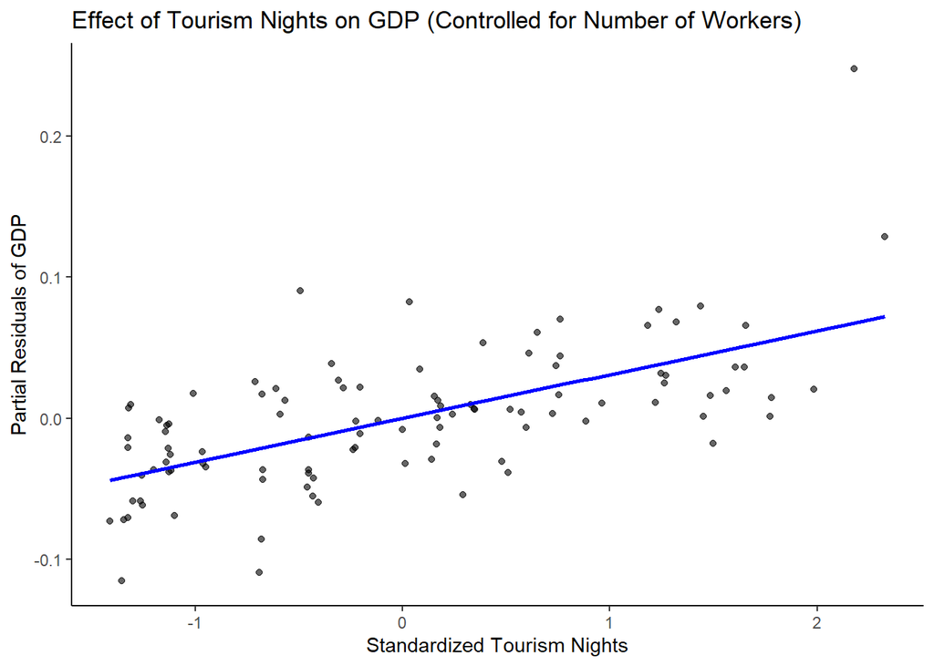

```r
# Calculate partial residuals for Tourism_Nights
partial_residuals <- resid(model) + model.matrix(model)[, "Tourism_Nights"] * fixef(model)["Tourism_Nights"]

# Add partial residuals to the data frame
combined_data_long$partial_residuals <- partial_residuals

# Plot the partial residuals showing the relationship between Tourism Nights and GDP
ggplot(combined_data_long, aes(x = Tourism_Nights, y = partial_residuals)) +
  geom_point(alpha = 0.6) +
  geom_smooth(method = "lm", se = FALSE, color = "blue") +
  labs(title = "Effect of Tourism Nights on GDP (Controlled for Number of Workers)",
       x = "Standardized Tourism Nights",
       y = "Partial Residuals of GDP",
      color = "Region") +
  theme_classic()
```

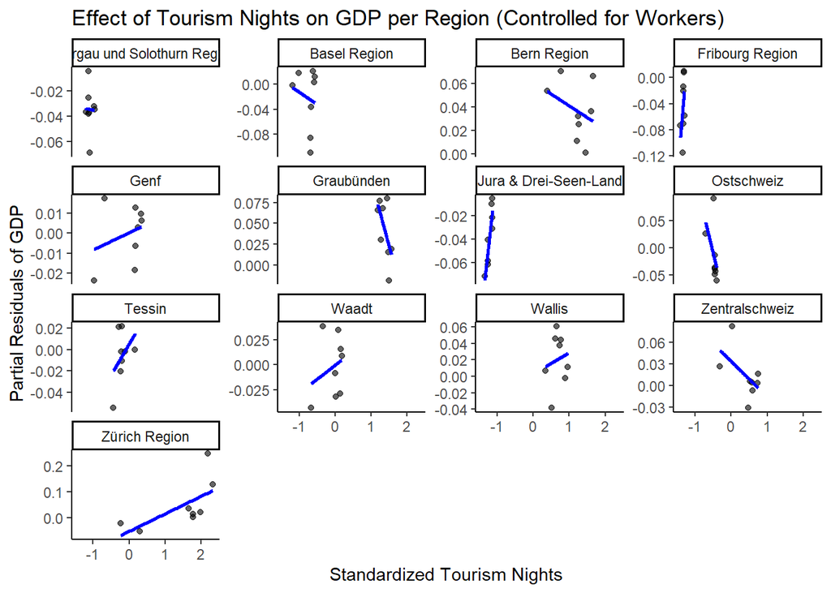

```r
# Save plot to output folder
ggsave("output/Effect of Tourism Nights on GDP (control for workers).png")
### Linear Mixed-Effects Model by Region
# Plot the partial residuals showing the relationship between Tourism Nights and GDP per Region
ggplot(combined_data_long, aes(x = Tourism_Nights, y = partial_residuals)) +
  geom_point(alpha = 0.6) +
  geom_smooth(method = "lm", se = FALSE, color = "blue") +
  facet_wrap(~ Region, scales = "free_y") +
  labs(title = "Effect of Tourism Nights on GDP per Region (Controlled for Workers)",
       x = "Standardized Tourism Nights",
       y = "Partial Residuals of GDP") +
  theme_classic() +
  theme(
    panel.background = element_rect(fill = "white"),
    plot.background = element_rect(fill = "white"),
    legend.background = element_rect(fill = "white"),
    legend.key = element_rect(fill = "white")
  )
```

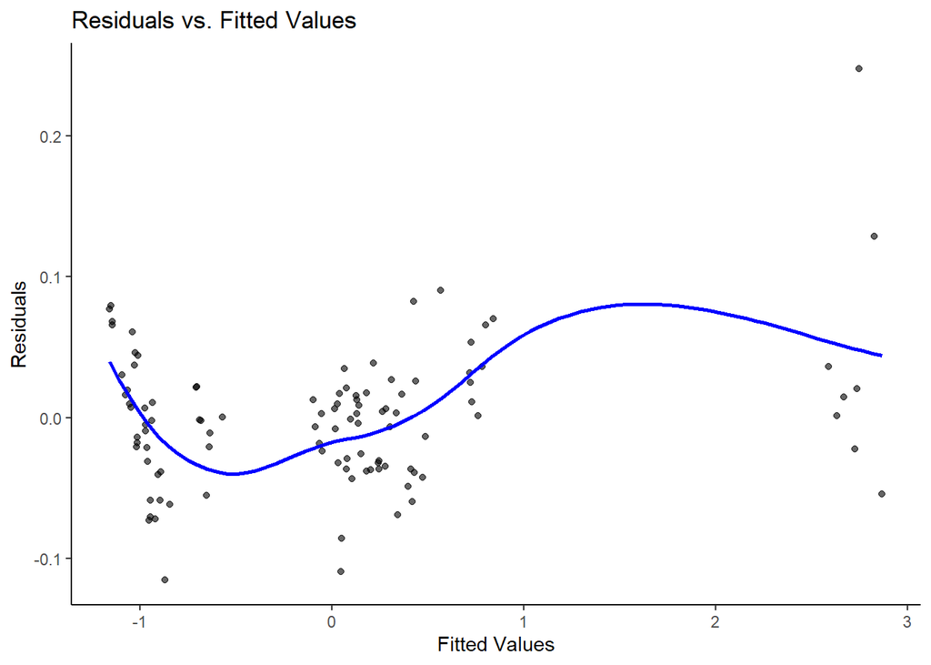

```r
# Save plot to output folder
ggsave("output/Effect of Tourism Nights on GDP per Region (control for workers).png")
## Check Residuals
# Fitted values from the model
fitted_values <- fitted(model)

# Add fitted values to the data frame
combined_data_long$fitted_values <- fitted_values

# Residuals vs. Fitted Values Plot
ggplot(combined_data_long, aes(x = fitted_values, y = partial_residuals)) +
  geom_point(alpha = 0.6) +
  geom_smooth(method = "loess", se = FALSE, color = "blue") +
  labs(title = "Residuals vs. Fitted Values",
       x = "Fitted Values",
       y = "Residuals") +
  theme_classic()
```

```r
# Save residuals vs. fitted values plot to output folder
ggsave("output/Residuals vs. Fitted Values.png")
### Polynomial model
# Adding polynomial terms to the model
model_poly <- lmer(GDP ~ poly(Tourism_Nights, 2) + workers + (1 | Region) + (1 | Year), data = combined_data_long)

# Summary of the polynomial model
summary(model_poly)
```

```
## Linear mixed model fit by REML ['lmerMod']
## Formula: GDP ~ poly(Tourism_Nights, 2) + workers + (1 | Region) + (1 |
##     Year)
##    Data: combined_data_long
##
## REML criterion at convergence: -255.5
##
## Scaled residuals:
##     Min      1Q  Median      3Q     Max
## -2.0899 -0.6543  0.0146  0.5636  3.8629
##
## Random effects:
##  Groups   Name        Variance Std.Dev.
##  Region   (Intercept) 0.137543 0.37087
##  Year     (Intercept) 0.002750 0.05244
##  Residual             0.001711 0.04137
## Number of obs: 104, groups:  Region, 13; Year, 8
##
## Fixed effects:
##                            Estimate Std. Error t value
## (Intercept)              -8.925e-14  1.046e-01   0.000
## poly(Tourism_Nights, 2)1 -8.932e-03  2.032e-01  -0.044
## poly(Tourism_Nights, 2)2  2.600e-01  9.942e-02   2.615
## workers                   8.813e-01  9.259e-02   9.518
##
## Correlation of Fixed Effects:
##             (Intr) p(T_N,2)1 p(T_N,2)2
## ply(T_N,2)1  0.000
## ply(T_N,2)2  0.000 -0.602
## workers      0.000  0.034     0.045
```

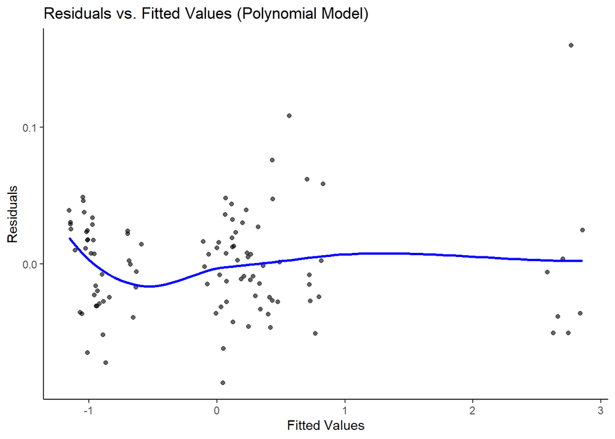

```r
# Diagnostic plots for the polynomial model
residuals_poly <- resid(model_poly)
fitted_values_poly <- fitted(model_poly)
combined_data_long$residuals_poly <- residuals_poly
combined_data_long$fitted_values_poly <- fitted_values_poly

# Residuals vs. Fitted Values Plot for the polynomial model
ggplot(combined_data_long, aes(x = fitted_values_poly, y = residuals_poly)) +
  geom_point(alpha = 0.6) +
  geom_smooth(method = "loess", se = FALSE, color = "blue") +
  labs(title = "Residuals vs. Fitted Values (Polynomial Model)",
       x = "Fitted Values",
       y = "Residuals") +
  theme_classic()
```

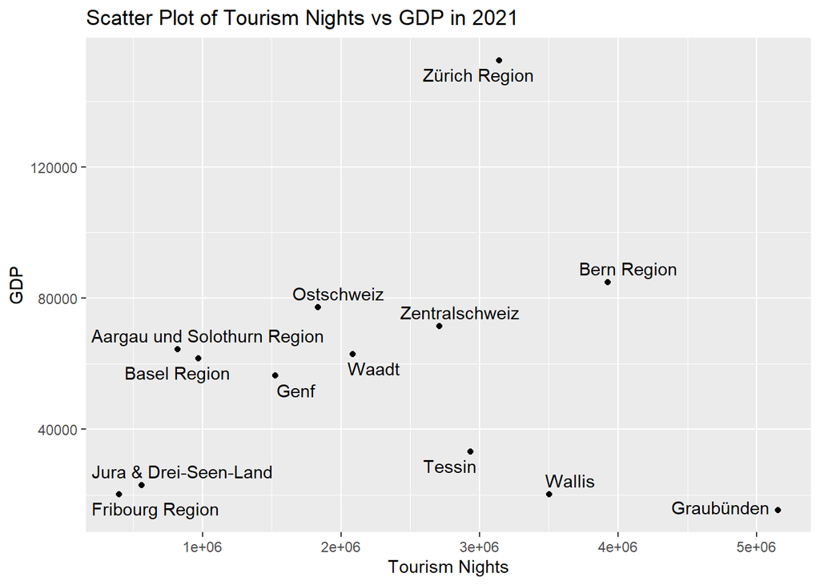

```r
# Save residuals vs. fitted values plot for polynomial model to output folder
ggsave("output/Residuals vs. Fitted Values (Polynomial Model).png")
### Scatter Plot of 2021 GDP vs Tourism Nights
# Plot scatter plot for 2021 with labeled points using ggplot2 and "combined_data" dataset
ggplot(combined_data, aes(x = `2021_Tourism_Nights`, y = `2021_GDP`, label = Region)) +
  geom_point() +
  geom_text_repel() +
  labs(title = "Scatter Plot of Tourism Nights vs GDP in 2021", x = "Tourism Nights", y = "GDP")
```

```r
# Save scatter plot to output folder
ggsave("output/scatter_plot_2021_gdp__vs_tourism.png")
```